# Exploring metabolism-growth relationships within and across individual fish.

# RMR MODEL

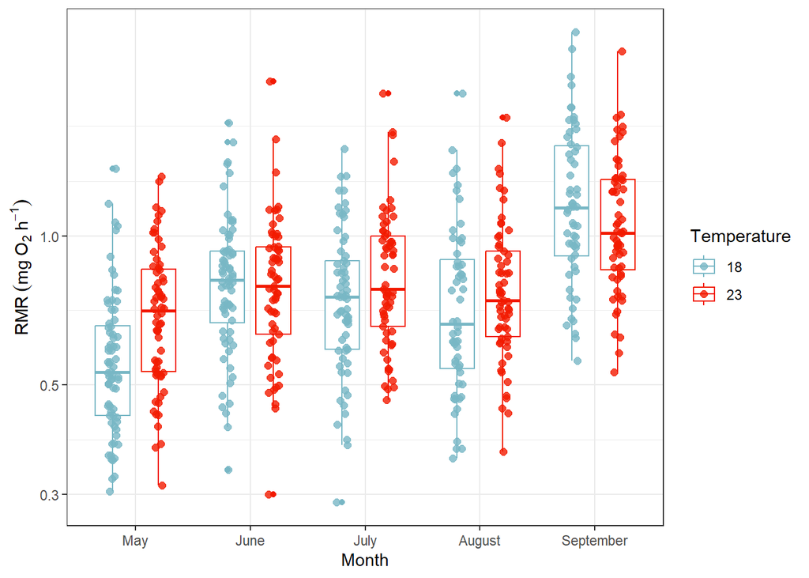

```r
#RMR over time, note that month is found below to be insignificant as a random effect, and RMR plotted here is not mass-standardized.
ggplot(ds1, aes(x = factor(Month), y = RMR, color = factor(Temp_class))) +
  geom_boxplot(position = position_dodge(width = 0.8), width = 0.6) +
  geom_point(position = position_jitterdodge(jitter.width = 0.2, dodge.width = 0.8), size = 2, alpha = 0.8) +
  labs(x = "Month", y = expression(RMR~(mg~O[2]~h^-1)), color = "Temperature") +
  theme_bw() +
  scale_color_manual(values = c("#78B7C5", "#F21A00")) +
  scale_y_log10()
```

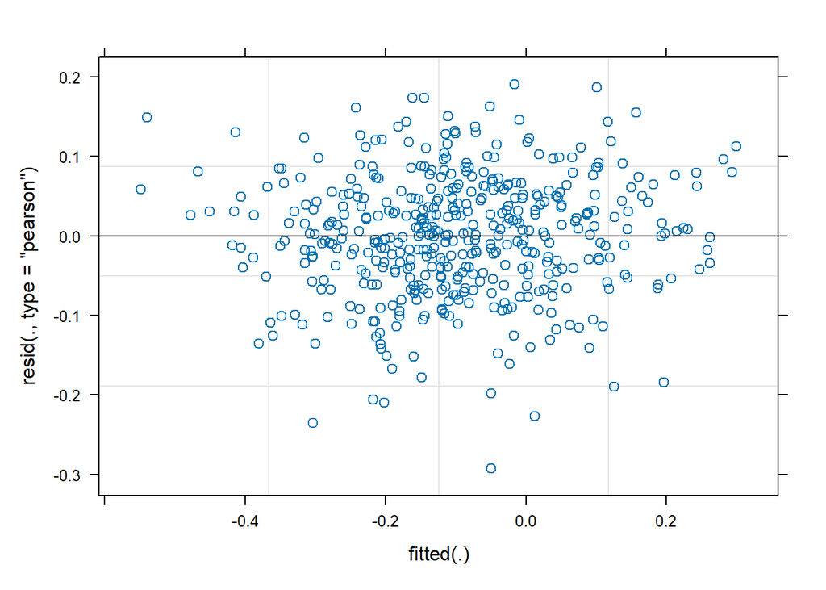

```r
# model using log10 RMR and the interaction of log10 mass and temperature treatment
RMR_mod <- lmer(log10(RMR) ~ log_mass*as.factor(Temp_class) + Sex  + Density + (1 |ID_fish),
                 data=ds1, REML=T)
plot(RMR_mod)
```

```r
summary(RMR_mod)
```

```
## Linear mixed model fit by REML. t-tests use Satterthwaite's method [
## lmerModLmerTest]
## Formula: log10(RMR) ~ log_mass * as.factor(Temp_class) + Sex + Density +
##     (1 | ID_fish)
##    Data: ds1
##
## REML criterion at convergence: -904.5
##
## Scaled residuals:
##     Min      1Q  Median      3Q     Max
## -3.6648 -0.6047  0.0301  0.6283  2.3881
##
## Random effects:
##  Groups   Name        Variance Std.Dev.
##  ID_fish  (Intercept) 0.001271 0.03565
##  Residual             0.006382 0.07989
## Number of obs: 453, groups:  ID_fish, 91
##
## Fixed effects:
##                                    Estimate Std. Error         df t value
## (Intercept)                       -0.477466   0.031210 209.423623 -15.299
## log_mass                           0.748665   0.027727 372.003883  27.002
## as.factor(Temp_class)23            0.160178   0.023555 263.936953   6.800
## SexM                               0.003446   0.011026  86.907311   0.313
## Density                           -0.004201   0.003524 211.056253  -1.192
## log_mass:as.factor(Temp_class)23  -0.154228   0.043250 358.764503  -3.566
##                                  Pr(>|t|)
## (Intercept)                       < 2e-16 ***
## log_mass                          < 2e-16 ***
## as.factor(Temp_class)23          6.96e-11 ***
## SexM                             0.755407
## Density                          0.234592
## log_mass:as.factor(Temp_class)23 0.000412 ***
## ---
## Signif. codes:  0 '***' 0.001 '**' 0.01 '*' 0.05 '.' 0.1 ' ' 1
##
## Correlation of Fixed Effects:
##             (Intr) lg_mss a.(T_) SexM   Densty
## log_mass    -0.605
## as.fc(T_)23 -0.457  0.614
## SexM        -0.202  0.177  0.061
## Density     -0.838  0.151  0.130 -0.013
## lg_:.(T_)23  0.400 -0.644 -0.884 -0.116 -0.111
```

```r
ranova(RMR_mod)
```

```
## ANOVA-like table for random-effects: Single term deletions
##
## Model:
## log10(RMR) ~ log_mass + as.factor(Temp_class) + Sex + Density + (1 | ID_fish) + log_mass:as.factor(Temp_class)
##               npar logLik     AIC    LRT Df Pr(>Chisq)
## <none>           8 452.24 -888.49
## (1 | ID_fish)    7 443.30 -872.60 17.886  1  2.345e-05 ***
## ---
## Signif. codes:  0 '***' 0.001 '**' 0.01 '*' 0.05 '.' 0.1 ' ' 1
```

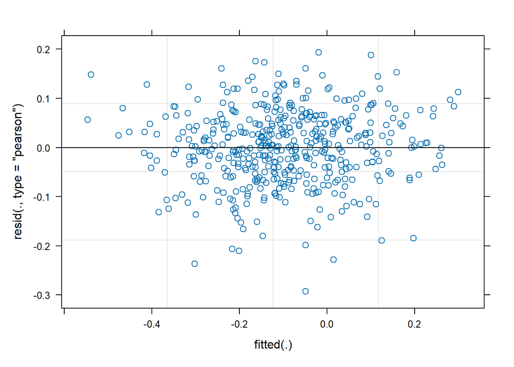

```r
# model using log10 SMR and the interaction of log10 mass and temperature treatment with test of random slopes by month
RMR_mod_month <- lmer(log10(RMR) ~ log_mass*as.factor(Temp_class) + Sex + Density + (1 + Month_int|ID_fish),
                 data=ds1, REML=T)
plot(RMR_mod_month)                                             # generate model output
```

```r
summary(RMR_mod_month)                                          # plot model residuals
```

```
## Linear mixed model fit by REML. t-tests use Satterthwaite's method [
## lmerModLmerTest]
## Formula: log10(RMR) ~ log_mass * as.factor(Temp_class) + Sex + Density +
##     (1 + Month_int | ID_fish)
##    Data: ds1
##
## REML criterion at convergence: -904.6
##
## Scaled residuals:
##     Min      1Q  Median      3Q     Max
## -3.6681 -0.5983  0.0284  0.6278  2.4239
##
## Random effects:
##  Groups   Name        Variance  Std.Dev. Corr
##  ID_fish  (Intercept) 1.509e-03 0.038848
##           Month_int   1.135e-06 0.001065 -1.00
##  Residual             6.380e-03 0.079873
## Number of obs: 453, groups:  ID_fish, 91
##
## Fixed effects:
##                                    Estimate Std. Error         df t value
## (Intercept)                       -0.476881   0.031184 208.946377 -15.293
## log_mass                           0.748619   0.027720 371.916742  27.006
## as.factor(Temp_class)23            0.159088   0.023714 198.905581   6.709
## SexM                               0.003107   0.011023  86.886610   0.282
## Density                           -0.004258   0.003515 203.921547  -1.211
## log_mass:as.factor(Temp_class)23  -0.153474   0.043242 358.751139  -3.549
##                                  Pr(>|t|)
## (Intercept)                       < 2e-16 ***
## log_mass                          < 2e-16 ***
## as.factor(Temp_class)23             2e-10 ***
## SexM                             0.778752
## Density                          0.227163
## log_mass:as.factor(Temp_class)23 0.000438 ***
## ---
## Signif. codes:  0 '***' 0.001 '**' 0.01 '*' 0.05 '.' 0.1 ' ' 1
##
## Correlation of Fixed Effects:
##             (Intr) lg_mss a.(T_) SexM   Densty
## log_mass    -0.610
## as.fc(T_)23 -0.458  0.615
## SexM        -0.203  0.178  0.064
## Density     -0.836  0.152  0.128 -0.012
## lg_:.(T_)23  0.404 -0.644 -0.886 -0.118 -0.112
## optimizer (nloptwrap) convergence code: 0 (OK)
## Model failed to converge with max|grad| = 0.00514734 (tol = 0.002, component 1)
```

```r
ranova(RMR_mod_month)                                           # anova-like test for significance of model components
```

```
## ANOVA-like table for random-effects: Single term deletions
##
## Model:
## log10(RMR) ~ log_mass + as.factor(Temp_class) + Sex + Density + (1 + Month_int | ID_fish) + log_mass:as.factor(Temp_class)
##                                        npar logLik     AIC      LRT Df
## <none>                                   10 452.28 -884.56
## Month_int in (1 + Month_int | ID_fish)    8 452.24 -888.49 0.076141  2
##                                        Pr(>Chisq)
## <none>
## Month_int in (1 + Month_int | ID_fish)     0.9626
```

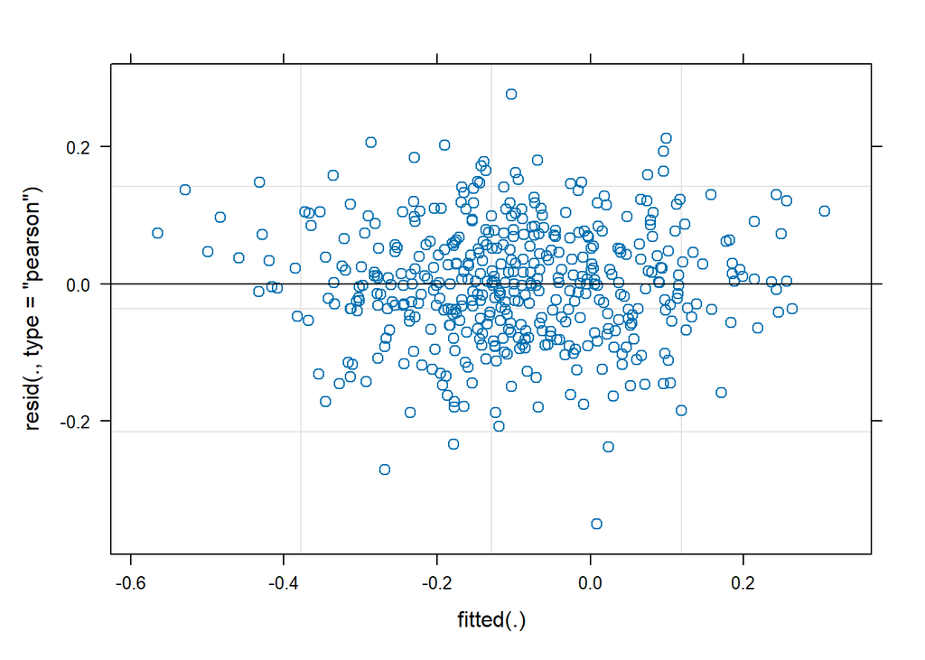

```r
# model with random intercepts by temp treatment
RMR_mod_trtint <- lmer(log10(RMR) ~ log_mass*as.factor(Temp_class) + Sex + Density + (1|Temp_class),
                 data=ds1, REML=T)
plot(RMR_mod_trtint)
```

```r
summary(RMR_mod_trtint)
```

```
## Linear mixed model fit by REML. t-tests use Satterthwaite's method [
## lmerModLmerTest]
## Formula: log10(RMR) ~ log_mass * as.factor(Temp_class) + Sex + Density +
##     (1 | Temp_class)
##    Data: ds1
##
## REML criterion at convergence: -886.6
##
## Scaled residuals:
##     Min      1Q  Median      3Q     Max
## -4.0205 -0.6163  0.0171  0.6597  3.1772
##
## Random effects:
##  Groups     Name        Variance  Std.Dev.
##  Temp_class (Intercept) 9.358e-05 0.009674
##  Residual               7.588e-03 0.087111
## Number of obs: 453, groups:  Temp_class, 2
##
## Fixed effects:
##                                    Estimate Std. Error         df t value
## (Intercept)                      -4.775e-01  2.868e-02  3.908e-08 -16.649
## log_mass                          7.495e-01  2.593e-02  4.470e+02  28.908
## as.factor(Temp_class)23           1.463e-01  2.518e-02  5.802e-09   5.811
## SexM                              3.679e-03  8.584e-03  4.470e+02   0.429
## Density                          -4.302e-03  3.044e-03  4.470e+02  -1.413
## log_mass:as.factor(Temp_class)23 -1.232e-01  4.012e-02  4.470e+02  -3.071
##                                  Pr(>|t|)
## (Intercept)                       1.00000
## log_mass                          < 2e-16 ***
## as.factor(Temp_class)23           1.00000
## SexM                              0.66846
## Density                           0.15824
## log_mass:as.factor(Temp_class)23  0.00226 **
## ---
## Signif. codes:  0 '***' 0.001 '**' 0.01 '*' 0.05 '.' 0.1 ' ' 1
##
## Correlation of Fixed Effects:
##             (Intr) lg_mss a.(T_) SexM   Densty
## log_mass    -0.576
## as.fc(T_)23 -0.510  0.538
## SexM        -0.197  0.216  0.081
## Density     -0.772  0.109  0.108 -0.021
## lg_:.(T_)23  0.404 -0.651 -0.768 -0.141 -0.111
```

```r
ranova(RMR_mod_trtint)
```

```
## ANOVA-like table for random-effects: Single term deletions
##
## Model:
## log10(RMR) ~ log_mass + as.factor(Temp_class) + Sex + Density + (1 | Temp_class) + log_mass:as.factor(Temp_class)
##                  npar logLik    AIC        LRT Df Pr(>Chisq)
## <none>              8  443.3 -870.6
## (1 | Temp_class)    7  443.3 -872.6 2.2737e-13  1          1
```

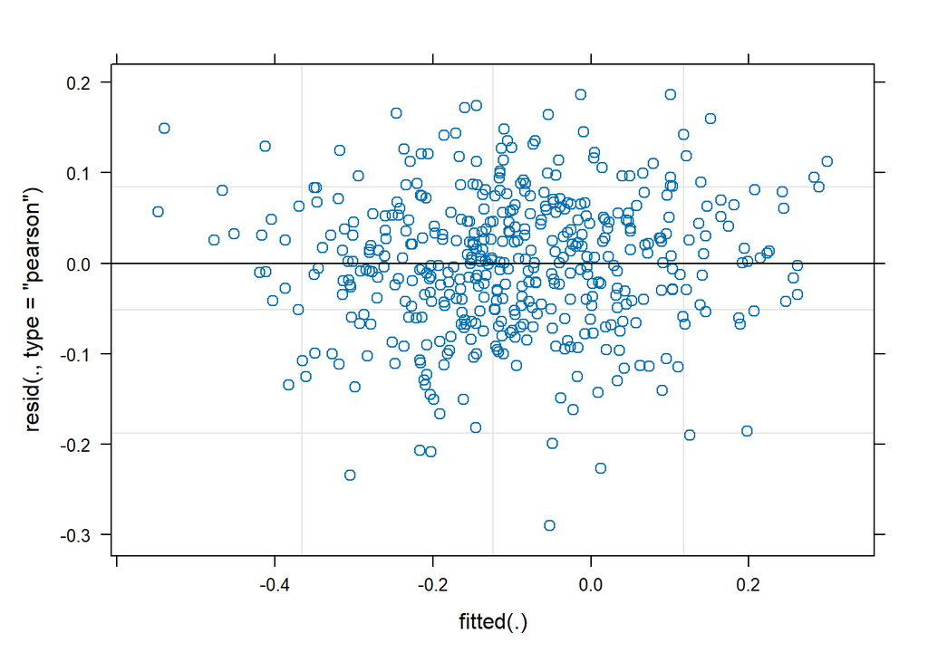

```r
# model with random slopes by temp treatment
RMR_mod_trt <- lmer(log10(RMR) ~ log_mass*as.factor(Temp_class) + Sex + Density + (0 + Temp_class|ID_fish),
                 data=ds1, REML=T)
plot(RMR_mod_trt)
```

```r
summary(RMR_mod_trt)
```

```
## Linear mixed model fit by REML. t-tests use Satterthwaite's method [
## lmerModLmerTest]
## Formula: log10(RMR) ~ log_mass * as.factor(Temp_class) + Sex + Density +
##     (0 + Temp_class | ID_fish)
##    Data: ds1
##
## REML criterion at convergence: -904.7
##
## Scaled residuals:
##     Min      1Q  Median      3Q     Max
## -3.6323 -0.5883  0.0271  0.6401  2.3369
##
## Random effects:
##  Groups   Name         Variance Std.Dev. Corr
##  ID_fish  Temp_class18 0.001392 0.03731
##           Temp_class23 0.001059 0.03254  0.15
##  Residual              0.006388 0.07992
## Number of obs: 453, groups:  ID_fish, 91
##
## Fixed effects:
##                                    Estimate Std. Error         df t value
## (Intercept)                       -0.476861   0.031190 208.937568 -15.289
## log_mass                           0.748448   0.027931 302.207977  26.796
## as.factor(Temp_class)23            0.158264   0.023388 232.444603   6.767
## SexM                               0.003190   0.010952  82.507699   0.291
## Density                           -0.004258   0.003507 196.713602  -1.214
## log_mass:as.factor(Temp_class)23  -0.150036   0.042951 298.007754  -3.493
##                                  Pr(>|t|)
## (Intercept)                       < 2e-16 ***
## log_mass                          < 2e-16 ***
## as.factor(Temp_class)23          1.06e-10 ***
## SexM                              0.77155
## Density                           0.22619
## log_mass:as.factor(Temp_class)23  0.00055 ***
## ---
## Signif. codes:  0 '***' 0.001 '**' 0.01 '*' 0.05 '.' 0.1 ' ' 1
##
## Correlation of Fixed Effects:
##             (Intr) lg_mss a.(T_) SexM   Densty
## log_mass    -0.607
## as.fc(T_)23 -0.470  0.624
## SexM        -0.197  0.169  0.057
## Density     -0.835  0.151  0.135 -0.013
## lg_:.(T_)23  0.410 -0.653 -0.886 -0.112 -0.117
## optimizer (nloptwrap) convergence code: 0 (OK)
## unable to evaluate scaled gradient
## Model failed to converge: degenerate  Hessian with 1 negative eigenvalues
```

```r
ranova(RMR_mod_trt)
```

```
## ANOVA-like table for random-effects: Single term deletions
##
## Model:
## log10(RMR) ~ log_mass + as.factor(Temp_class) + Sex + Density + (0 + Temp_class | ID_fish) + log_mass:as.factor(Temp_class)
##                                          npar logLik     AIC     LRT Df
## <none>                                     10 452.33 -884.66
## Temp_class in (0 + Temp_class | ID_fish)    8 452.24 -888.49 0.17085  2
##                                          Pr(>Chisq)
## <none>
## Temp_class in (0 + Temp_class | ID_fish)     0.9181
```

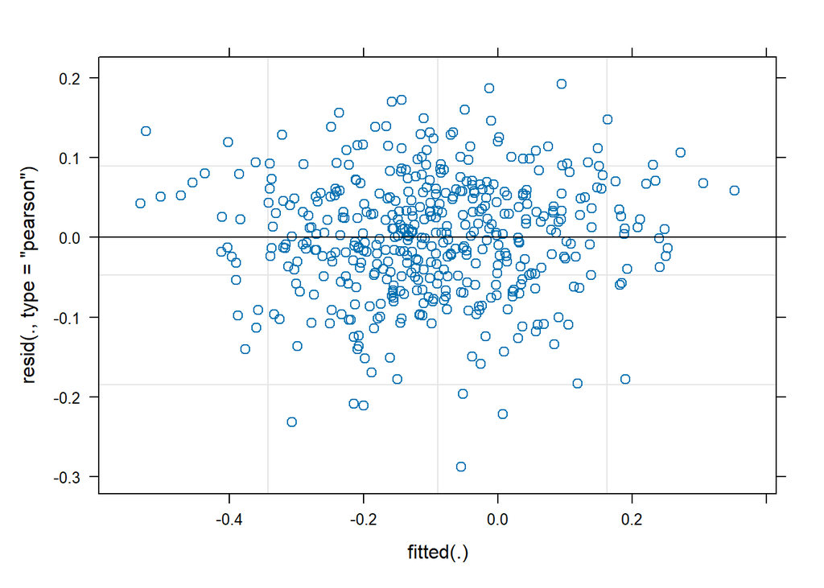

```r
# test sex terms for model inclusion

RMR_mod_sex <- lmer(log10(RMR) ~ 0 + as.factor(Sex):as.factor(Temp_class) + as.factor(Sex):as.factor(Temp_class):log_mass + Density + (1 |ID_fish),
                 data=ds1, REML=T)
plot(RMR_mod_sex)
```

```r
summary(RMR_mod_sex)
```

```
## Linear mixed model fit by REML. t-tests use Satterthwaite's method [
## lmerModLmerTest]
## Formula:
## log10(RMR) ~ 0 + as.factor(Sex):as.factor(Temp_class) + as.factor(Sex):as.factor(Temp_class):log_mass +
##     Density + (1 | ID_fish)
##    Data: ds1
##
## REML criterion at convergence: -895.9
##
## Scaled residuals:
##     Min      1Q  Median      3Q     Max
## -3.6217 -0.6035  0.0362  0.6597  2.4226
##
## Random effects:
##  Groups   Name        Variance Std.Dev.
##  ID_fish  (Intercept) 0.001370 0.03701
##  Residual             0.006309 0.07943
## Number of obs: 453, groups:  ID_fish, 91
##
## Fixed effects:
##                                                    Estimate Std. Error
## Density                                           -0.004299   0.003555
## as.factor(Sex)F:as.factor(Temp_class)18           -0.458863   0.033569
## as.factor(Sex)M:as.factor(Temp_class)18           -0.512022   0.037156
## as.factor(Sex)F:as.factor(Temp_class)23           -0.325311   0.035831
## as.factor(Sex)M:as.factor(Temp_class)23           -0.308350   0.032984
## as.factor(Sex)F:as.factor(Temp_class)18:log_mass   0.715302   0.032984
## as.factor(Sex)M:as.factor(Temp_class)18:log_mass   0.839690   0.052870
## as.factor(Sex)F:as.factor(Temp_class)23:log_mass   0.617900   0.056382
## as.factor(Sex)M:as.factor(Temp_class)23:log_mass   0.579006   0.041101
##                                                          df t value Pr(>|t|)
## Density                                          213.356426  -1.209    0.228
## as.factor(Sex)F:as.factor(Temp_class)18          211.189136 -13.669   <2e-16
## as.factor(Sex)M:as.factor(Temp_class)18          283.322955 -13.780   <2e-16
## as.factor(Sex)F:as.factor(Temp_class)23          200.632088  -9.079   <2e-16
## as.factor(Sex)M:as.factor(Temp_class)23          207.520955  -9.348   <2e-16
## as.factor(Sex)F:as.factor(Temp_class)18:log_mass 359.999351  21.686   <2e-16
## as.factor(Sex)M:as.factor(Temp_class)18:log_mass 439.883035  15.882   <2e-16
## as.factor(Sex)F:as.factor(Temp_class)23:log_mass 294.895487  10.959   <2e-16
## as.factor(Sex)M:as.factor(Temp_class)23:log_mass 367.788434  14.088   <2e-16
```

[output cut: 17 more lines]

```
## as.(S)F:.(T_)23 -0.620  0.490           0.441
## as.(S)M:.(T_)23 -0.731  0.578           0.520           0.453
## a.(S)F:.(T_)18:  0.134 -0.655          -0.095          -0.083
## a.(S)M:.(T_)18:  0.080 -0.063          -0.687          -0.050
## a.(S)F:.(T_)23: -0.049  0.039           0.035          -0.681
## a.(S)M:.(T_)23:  0.015 -0.012          -0.011          -0.010
##                 as.(S)M:.(T_)23 a.(S)F:.(T_)18: a.(S)M:.(T_)18: a.(S)F:.(T_)23:
## as.(S)F:.(T_)18
## as.(S)M:.(T_)18
## as.(S)F:.(T_)23
## as.(S)M:.(T_)23
## a.(S)F:.(T_)18: -0.098
## a.(S)M:.(T_)18: -0.059           0.011
## a.(S)F:.(T_)23:  0.036          -0.007          -0.004
## a.(S)M:.(T_)23: -0.579           0.002           0.001          -0.001
```

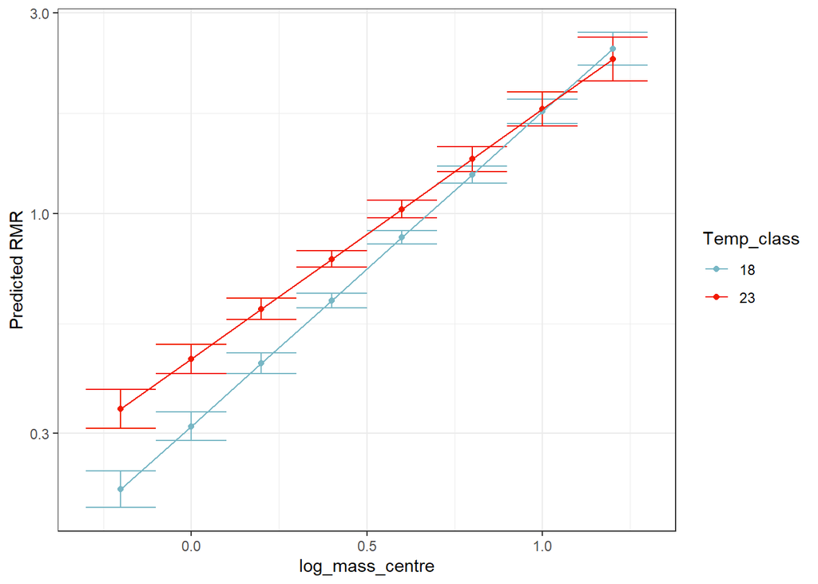

```r
# plot RMR vs. log mass mean predicted level

pred_RMR <- ggpredict(RMR_mod, terms = c("log_mass", "Temp_class"))

ggplot() +
  geom_errorbar(data = pred_RMR, aes(x=x, ymin = conf.low, ymax = conf.high, color = group, group = group), width = 0.2) +   # add error bars showing 95% confidence intervals
  geom_point(data = pred_RMR, aes(x = x, y = predicted, color = group, group = group)) +
  geom_line(data = pred_RMR, aes(x = x, y = predicted, color = group, group = group)) +
  labs(x = "log_mass_centre", y = "Predicted RMR", color = "Temp_class") +
  theme_bw() +
  scale_color_manual(values = c("#78B7C5", "#F21A00")) +
  scale_y_log10()
```

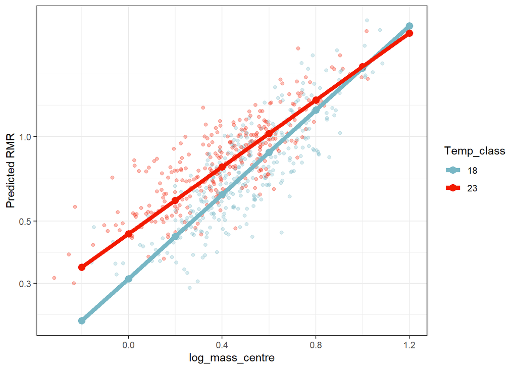

```r
# plot the raw data as a cloud around the predictions

ggplot() +
  geom_point(data = ds1, aes(x = log_mass, y = RMR, group = factor(Temp_class), color = factor(Temp_class)),
             alpha = 0.3, position = position_jitter(width = 0.1)) +
  geom_point(data = pred_RMR, aes(x = x, y = predicted, color = group, group = group),
             size = 3) +
  geom_line(data = pred_RMR, aes(x = x, y = predicted, color = group, group = group),
            size = 2) +
  labs(x = "log_mass_centre", y = "Predicted RMR", color = "Temp_class") +
  theme_bw() +
  scale_color_manual(values = c("#78B7C5", "#F21A00")) +
  scale_y_log10()
```

```r
# F test on interaction effect

anova(RMR_mod, type = "3")
```

```
## Type III Analysis of Variance Table with Satterthwaite's method
##                                Sum Sq Mean Sq NumDF  DenDF  F value    Pr(>F)
## log_mass                       6.1966  6.1966     1 348.36 970.8964 < 2.2e-16
## as.factor(Temp_class)          0.2951  0.2951     1 263.94  46.2406 6.964e-11
## Sex                            0.0006  0.0006     1  86.91   0.0977 0.7554072
## Density                        0.0091  0.0091     1 211.06   1.4209 0.2345922
## log_mass:as.factor(Temp_class) 0.0812  0.0812     1 358.76  12.7161 0.0004116
##
## log_mass                       ***
## as.factor(Temp_class)          ***
## Sex
## Density
## log_mass:as.factor(Temp_class) ***
## ---
## Signif. codes:  0 '***' 0.001 '**' 0.01 '*' 0.05 '.' 0.1 ' ' 1
```

```r
# generate fitted data

z_RMR<-augment(RMR_mod)                                            # get variables and fitted values from model
head(z_RMR)
```

```
## # A tibble: 6 × 18
##   .rownames `log10(RMR)` log_mass `as.factor(Temp_class)` Sex   Density ID_fish
##   <chr>            <dbl>    <dbl> <fct>                   <fct>   <dbl>   <dbl>
## 1 1             -0.0212    0.423  23                      F           8      81
## 2 2             -0.386    -0.0915 23                      M           8      82
## 3 3             -0.147     0.250  23                      F           8      83
## 4 4              0.00674   0.436  23                      M           8      84
## 5 5             -0.0573    0.360  23                      M           8      85
## 6 7             -0.161     0.310  23                      M           8      87
## # ℹ 11 more variables: .fitted <dbl>, .resid <dbl>, .hat <dbl>, .cooksd <dbl>,
## #   .fixed <dbl>, .mu <dbl>, .offset <dbl>, .sqrtXwt <dbl>, .sqrtrwt <dbl>,
## #   .weights <dbl>, .wtres <dbl>
```

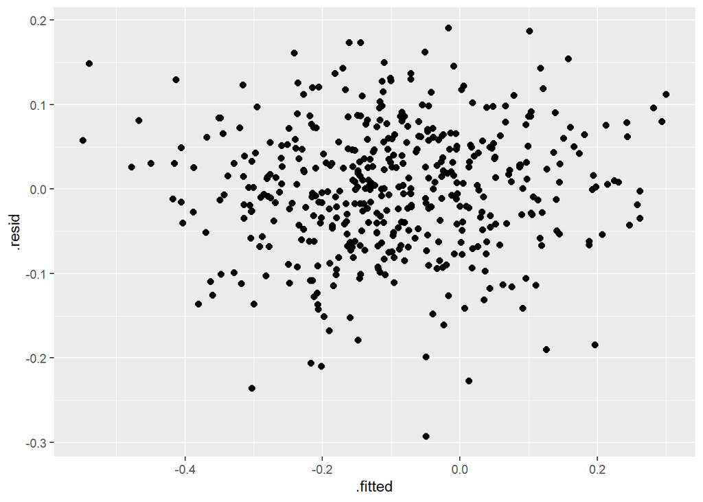

```r
z_RMR <- z_RMR %>%
  mutate(
    pwr.fitted = 10^(.fitted)
  )

# check assumptions: plot all residual values against the fitted

ggplot(z_RMR, aes(x = .fitted, y = .resid)) +                      # same plot as before
  geom_point(size = 2)
```

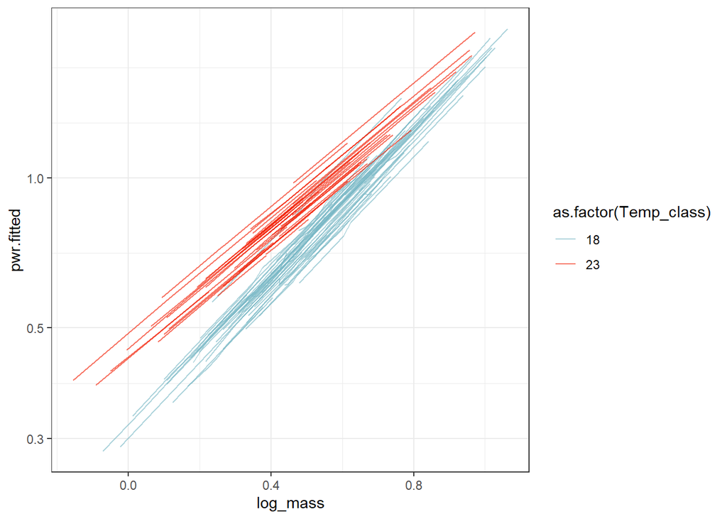

```r
ggplot(z_RMR, aes(x = log_mass, y = RMR, group = ID_fish)) +
  geom_line(aes(y = pwr.fitted, color = `as.factor(Temp_class)`),
            alpha = 0.6) +
  theme_bw() +
  scale_y_log10() +
  scale_color_manual(values  = c("#78B7C5", "#F21A00"))
```

# MMR MODEL

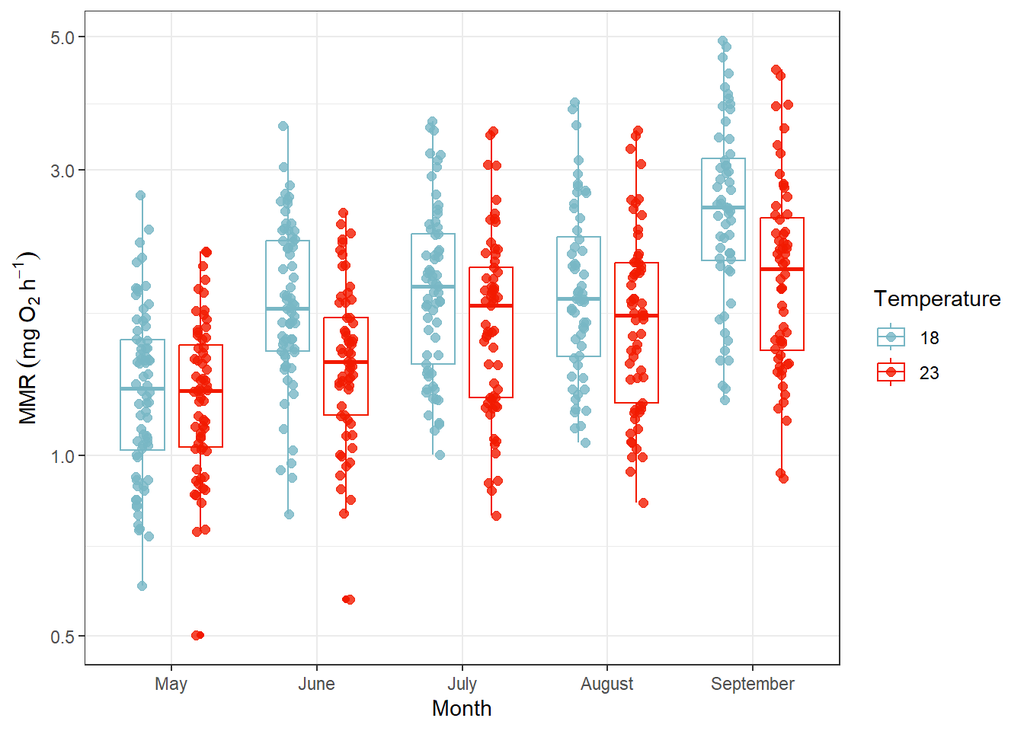

```r
#MMR over time, note that month is found below to be insignificant as a random effect, and MMR plotted here is not mass-standardized.
ggplot(ds1, aes(x = factor(Month), y = MMR, color = factor(Temp_class))) +
  geom_boxplot(position = position_dodge(width = 0.8), width = 0.6) +
  geom_point(position = position_jitterdodge(jitter.width = 0.2, dodge.width = 0.8), size = 2, alpha = 0.8) +
  labs(x = "Month", y = expression(MMR~(mg~O[2]~h^-1)), color = "Temperature") +
  theme_bw() +
  scale_color_manual(values = c("#78B7C5", "#F21A00")) +
  scale_y_log10()
```

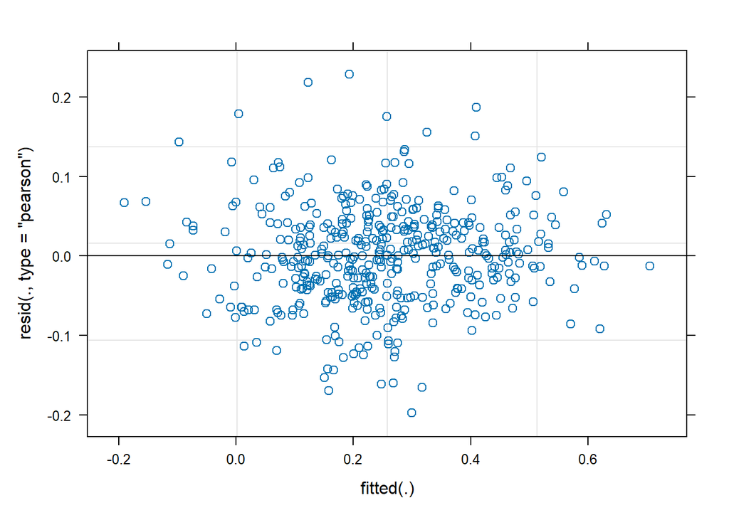

```r
# model using log10 MMR and the interaction of log10 mass and temperature treatment

MMR_mod <- lmer(log10(MMR) ~ log_mass*as.factor(Temp_class) + Sex + Density + (1 |ID_fish),
                 data=ds1, REML=T)

plot(MMR_mod)
```

```r
summary(MMR_mod)
```

```
## Linear mixed model fit by REML. t-tests use Satterthwaite's method [
## lmerModLmerTest]
## Formula: log10(MMR) ~ log_mass * as.factor(Temp_class) + Sex + Density +
##     (1 | ID_fish)
##    Data: ds1
##
## REML criterion at convergence: -1086.6
##
## Scaled residuals:
##     Min      1Q  Median      3Q     Max
## -3.0358 -0.6335  0.0066  0.5706  3.5127
##
## Random effects:
##  Groups   Name        Variance  Std.Dev.
##  ID_fish  (Intercept) 0.0008517 0.02918
##  Residual             0.0042430 0.06514
## Number of obs: 453, groups:  ID_fish, 91
##
## Fixed effects:
##                                    Estimate Std. Error         df t value
## (Intercept)                       -0.034542   0.025478 210.005598  -1.356
## log_mass                           0.718537   0.022624 372.713216  31.760
## as.factor(Temp_class)23            0.050788   0.019226 264.403760   2.642
## SexM                               0.026480   0.009007  86.996070   2.940
## Density                           -0.012575   0.002877 211.708210  -4.371
## log_mass:as.factor(Temp_class)23  -0.096076   0.035291 359.553907  -2.722
##                                  Pr(>|t|)
## (Intercept)                       0.17663
## log_mass                          < 2e-16 ***
## as.factor(Temp_class)23           0.00874 **
## SexM                              0.00421 **
## Density                          1.94e-05 ***
## log_mass:as.factor(Temp_class)23  0.00680 **
## ---
## Signif. codes:  0 '***' 0.001 '**' 0.01 '*' 0.05 '.' 0.1 ' ' 1
##
## Correlation of Fixed Effects:
##             (Intr) lg_mss a.(T_) SexM   Densty
## log_mass    -0.605
## as.fc(T_)23 -0.457  0.614
## SexM        -0.202  0.176  0.060
## Density     -0.838  0.152  0.130 -0.013
## lg_:.(T_)23  0.400 -0.644 -0.884 -0.115 -0.111
```

```r
ranova(MMR_mod)
```

```
## ANOVA-like table for random-effects: Single term deletions
##
## Model:
## log10(MMR) ~ log_mass + as.factor(Temp_class) + Sex + Density + (1 | ID_fish) + log_mass:as.factor(Temp_class)
##               npar logLik     AIC    LRT Df Pr(>Chisq)
## <none>           8 543.31 -1070.6
## (1 | ID_fish)    7 534.20 -1054.4 18.232  1  1.956e-05 ***
## ---
## Signif. codes:  0 '***' 0.001 '**' 0.01 '*' 0.05 '.' 0.1 ' ' 1
```

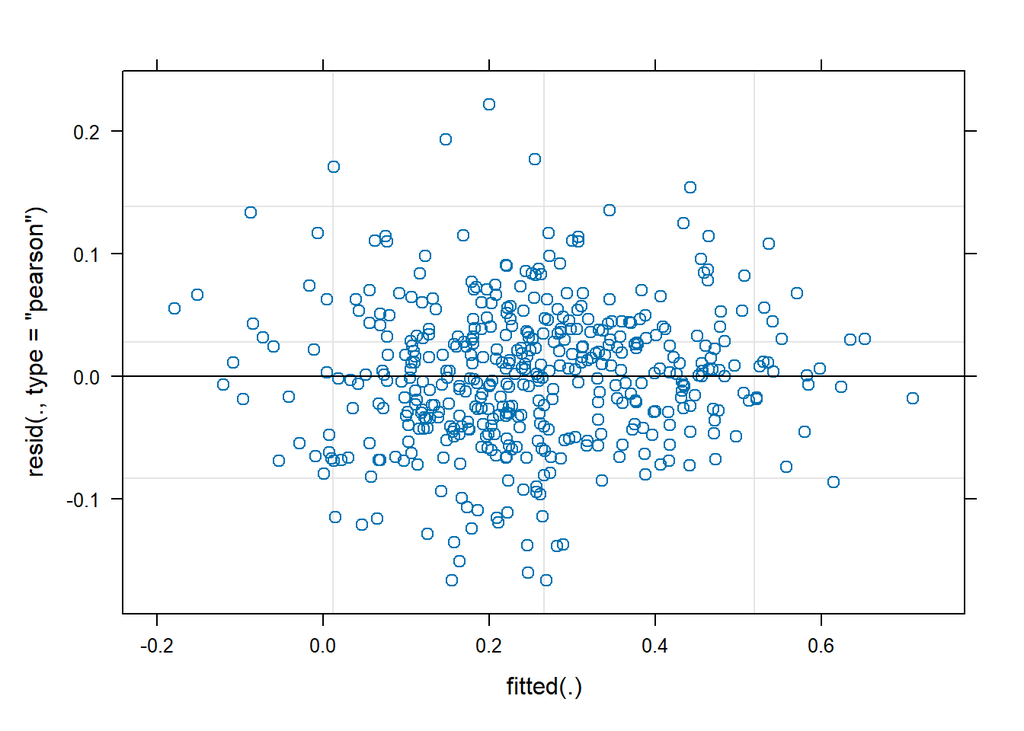

```r
# model using log10 SMR and the interaction of log10 mass and temperature treatment with test of random slopes by month
MMR_mod_month <- lmer(log10(MMR) ~ log_mass*as.factor(Temp_class) + Sex + Density + (1 + Month_int|ID_fish),
                 data=ds1, REML=T)
plot(MMR_mod_month)                                             # generate model output
```

```r
summary(MMR_mod_month)                                          # plot model residuals
```

```
## Linear mixed model fit by REML. t-tests use Satterthwaite's method [
## lmerModLmerTest]
## Formula: log10(MMR) ~ log_mass * as.factor(Temp_class) + Sex + Density +
##     (1 + Month_int | ID_fish)
##    Data: ds1
##
## REML criterion at convergence: -1090.5
##
## Scaled residuals:
##     Min      1Q  Median      3Q     Max
## -2.6553 -0.6206  0.0243  0.5554  3.5381
##
## Random effects:
##  Groups   Name        Variance  Std.Dev. Corr
##  ID_fish  (Intercept) 0.0013142 0.03625
##           Month_int   0.0001224 0.01106  -0.62
##  Residual             0.0039368 0.06274
## Number of obs: 453, groups:  ID_fish, 91
##
## Fixed effects:
##                                    Estimate Std. Error         df t value
## (Intercept)                       -0.037512   0.025652 199.690054  -1.462
## log_mass                           0.716517   0.023329 271.438607  30.714
## as.factor(Temp_class)23            0.051810   0.019205 169.950435   2.698
## SexM                               0.028424   0.008949  87.097271   3.176
## Density                           -0.012195   0.002938 191.627985  -4.151
## log_mass:as.factor(Temp_class)23  -0.096354   0.036605 238.653992  -2.632
##                                  Pr(>|t|)
## (Intercept)                       0.14523
## log_mass                          < 2e-16 ***
## as.factor(Temp_class)23           0.00768 **
## SexM                              0.00206 **
## Density                          4.99e-05 ***
## log_mass:as.factor(Temp_class)23  0.00903 **
## ---
## Signif. codes:  0 '***' 0.001 '**' 0.01 '*' 0.05 '.' 0.1 ' ' 1
##
## Correlation of Fixed Effects:
##             (Intr) lg_mss a.(T_) SexM   Densty
## log_mass    -0.576
## as.fc(T_)23 -0.449  0.613
## SexM        -0.195  0.178  0.055
## Density     -0.840  0.116  0.123 -0.019
## lg_:.(T_)23  0.382 -0.639 -0.885 -0.108 -0.093
```

```r
ranova(MMR_mod_month)                                           # anova-like test for significance of model components
```

```
## ANOVA-like table for random-effects: Single term deletions
##
## Model:
## log10(MMR) ~ log_mass + as.factor(Temp_class) + Sex + Density + (1 + Month_int | ID_fish) + log_mass:as.factor(Temp_class)
##                                        npar logLik     AIC    LRT Df Pr(>Chisq)
## <none>                                   10 545.27 -1070.5
## Month_int in (1 + Month_int | ID_fish)    8 543.31 -1070.6 3.9032  2      0.142
```

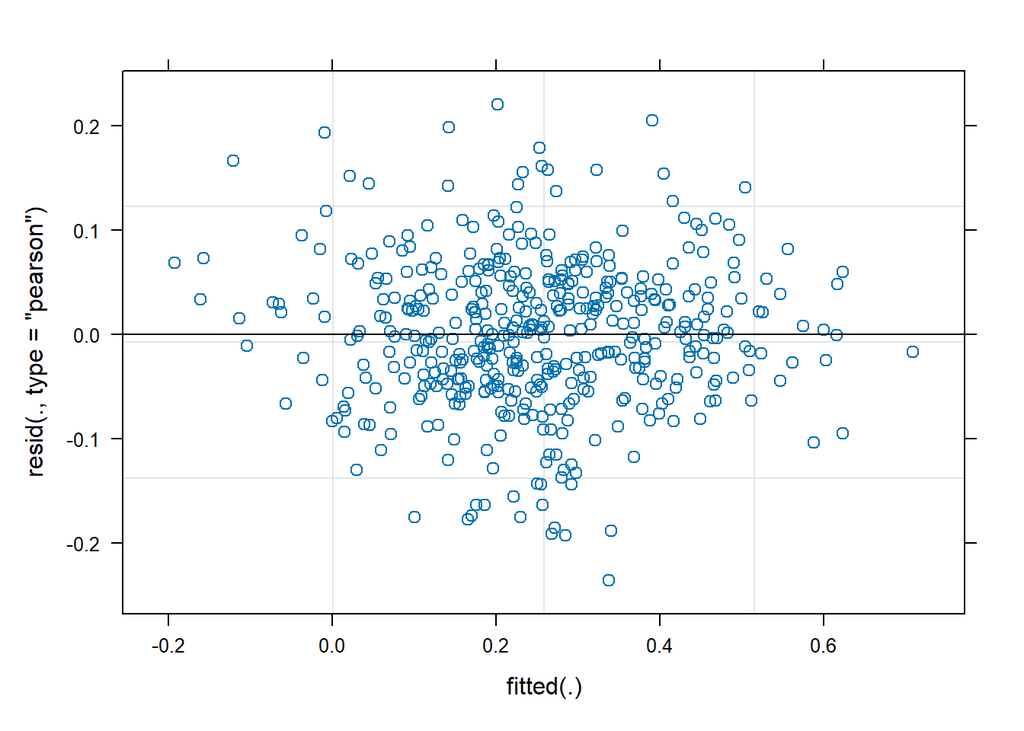

```r
# model with random intercepts by temp treatment
MMR_mod_trtint <- lmer(log10(MMR) ~ log_mass*as.factor(Temp_class) + Sex + Density + (1|Temp_class),
                 data=ds1, REML=T)

plot(MMR_mod_trtint)
```

```r
summary(MMR_mod_trtint)
```

```
## Linear mixed model fit by REML. t-tests use Satterthwaite's method [
## lmerModLmerTest]
## Formula: log10(MMR) ~ log_mass * as.factor(Temp_class) + Sex + Density +
##     (1 | Temp_class)
##    Data: ds1
##
## REML criterion at convergence: -1068.4
##
## Scaled residuals:
##     Min      1Q  Median      3Q     Max
## -3.3156 -0.6143  0.0195  0.6269  3.1035
##
## Random effects:
##  Groups     Name        Variance  Std.Dev.
##  Temp_class (Intercept) 6.744e-05 0.008212
##  Residual               5.053e-03 0.071082
## Number of obs: 453, groups:  Temp_class, 2
##
## Fixed effects:
##                                    Estimate Std. Error         df t value
## (Intercept)                      -5.223e-02  2.351e-02  1.327e-07  -2.221
## log_mass                          7.324e-01  2.116e-02  4.470e+02  34.618
## as.factor(Temp_class)23           5.136e-02  2.079e-02  2.029e-08   2.470
## SexM                              2.738e-02  7.005e-03  4.470e+02   3.909
## Density                          -1.111e-02  2.484e-03  4.470e+02  -4.473
## log_mass:as.factor(Temp_class)23 -9.468e-02  3.274e-02  4.470e+02  -2.892
##                                  Pr(>|t|)
## (Intercept)                      0.999999
## log_mass                          < 2e-16 ***
## as.factor(Temp_class)23          1.000000
## SexM                             0.000107 ***
## Density                          9.79e-06 ***
## log_mass:as.factor(Temp_class)23 0.004014 **
## ---
## Signif. codes:  0 '***' 0.001 '**' 0.01 '*' 0.05 '.' 0.1 ' ' 1
##
## Correlation of Fixed Effects:
##             (Intr) lg_mss a.(T_) SexM   Densty
## log_mass    -0.574
## as.fc(T_)23 -0.512  0.532
## SexM        -0.196  0.216  0.080
## Density     -0.768  0.109  0.107 -0.021
## lg_:.(T_)23  0.402 -0.651 -0.759 -0.141 -0.111
```

```r
ranova(MMR_mod_trtint)
```

```
## ANOVA-like table for random-effects: Single term deletions
##
## Model:
## log10(MMR) ~ log_mass + as.factor(Temp_class) + Sex + Density + (1 | Temp_class) + log_mass:as.factor(Temp_class)
##                  npar logLik     AIC        LRT Df Pr(>Chisq)
## <none>              8  534.2 -1052.4
## (1 | Temp_class)    7  534.2 -1054.4 6.8212e-13  1          1
```

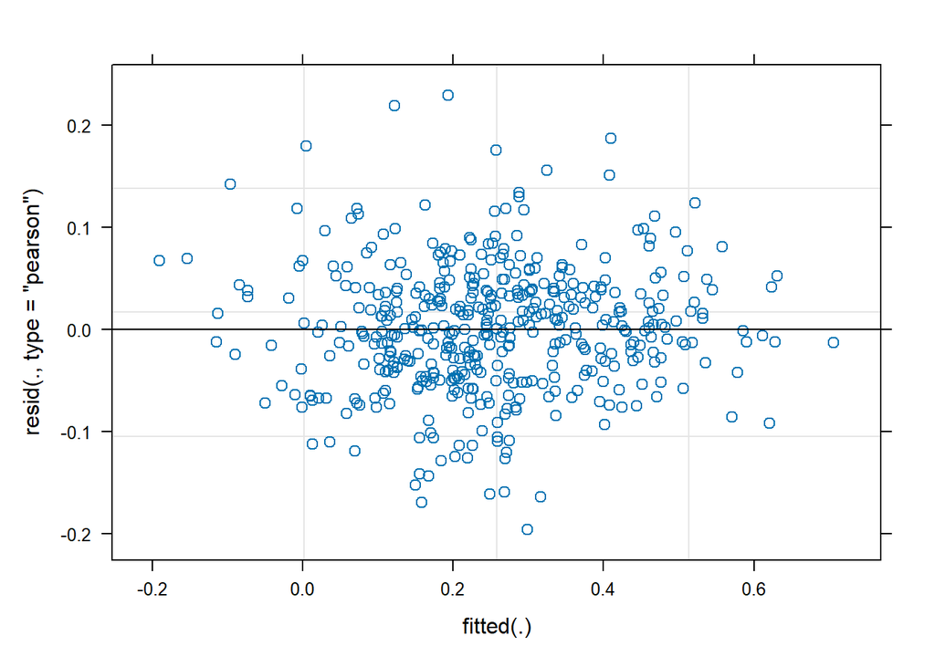

```r
# model with random slopes by temp treatment
MMR_mod_trt <- lmer(log10(MMR) ~ log_mass*as.factor(Temp_class) + Sex + Density + (0 + Temp_class|ID_fish),
                 data=ds1, REML=T)

plot(MMR_mod_trt)
```

```r
summary(MMR_mod_trt)
```

```
## Linear mixed model fit by REML. t-tests use Satterthwaite's method [
## lmerModLmerTest]
## Formula: log10(MMR) ~ log_mass * as.factor(Temp_class) + Sex + Density +
##     (0 + Temp_class | ID_fish)
##    Data: ds1
##
## REML criterion at convergence: -1086.7
##
## Scaled residuals:
##     Min      1Q  Median      3Q     Max
## -3.0147 -0.6251  0.0075  0.5777  3.5188
##
## Random effects:
##  Groups   Name         Variance  Std.Dev. Corr
##  ID_fish  Temp_class18 0.0008129 0.02851
##           Temp_class23 0.0009152 0.03025  0.43
##  Residual              0.0042424 0.06513
## Number of obs: 453, groups:  ID_fish, 91
##
## Fixed effects:
##                                    Estimate Std. Error         df t value
## (Intercept)                       -0.034292   0.025461 208.686591  -1.347
## log_mass                           0.718885   0.022540 289.137042  31.894
## as.factor(Temp_class)23            0.051319   0.019279 235.372611   2.662
## SexM                               0.026620   0.009019  86.512834   2.952
## Density                           -0.012647   0.002880 209.059535  -4.391
## log_mass:as.factor(Temp_class)23  -0.097241   0.035385 315.337174  -2.748
##                                  Pr(>|t|)
## (Intercept)                       0.17950
## log_mass                          < 2e-16 ***
## as.factor(Temp_class)23           0.00831 **
## SexM                              0.00407 **
## Density                          1.79e-05 ***
## log_mass:as.factor(Temp_class)23  0.00634 **
## ---
## Signif. codes:  0 '***' 0.001 '**' 0.01 '*' 0.05 '.' 0.1 ' ' 1
##
## Correlation of Fixed Effects:
##             (Intr) lg_mss a.(T_) SexM   Densty
## log_mass    -0.604
## as.fc(T_)23 -0.451  0.609
## SexM        -0.204  0.180  0.062
## Density     -0.839  0.151  0.128 -0.012
## lg_:.(T_)23  0.396 -0.639 -0.883 -0.117 -0.109
```

```r
ranova(MMR_mod_trt)
```

```
## ANOVA-like table for random-effects: Single term deletions
##
## Model:
## log10(MMR) ~ log_mass + as.factor(Temp_class) + Sex + Density + (0 + Temp_class | ID_fish) + log_mass:as.factor(Temp_class)
##                                          npar logLik     AIC      LRT Df
## <none>                                     10 543.33 -1066.7
## Temp_class in (0 + Temp_class | ID_fish)    8 543.31 -1070.6 0.035729  2
##                                          Pr(>Chisq)
## <none>
## Temp_class in (0 + Temp_class | ID_fish)     0.9823
```

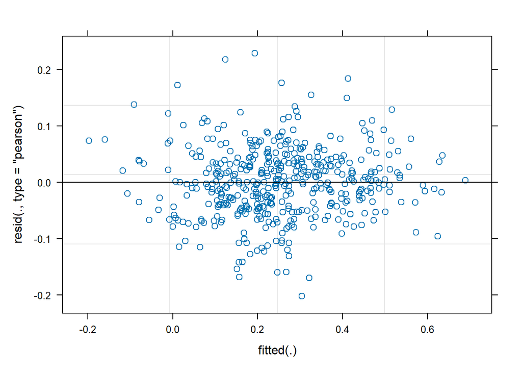

```r
# test sex terms for model inclusion
MMR_mod_sex <- lmer(log10(MMR) ~ 0 + as.factor(Sex):as.factor(Temp_class) + as.factor(Sex):as.factor(Temp_class):log_mass + Density + (1 |ID_fish),
                 data=ds1, REML=T)
plot(MMR_mod_sex)
```

```r
summary(MMR_mod_sex)
```

```
## Linear mixed model fit by REML. t-tests use Satterthwaite's method [
## lmerModLmerTest]
## Formula:
## log10(MMR) ~ 0 + as.factor(Sex):as.factor(Temp_class) + as.factor(Sex):as.factor(Temp_class):log_mass +
##     Density + (1 | ID_fish)
##    Data: ds1
##
## REML criterion at convergence: -1073.9
##
## Scaled residuals:
##     Min      1Q  Median      3Q     Max
## -3.1037 -0.6119  0.0047  0.5638  3.5177
##
## Random effects:
##  Groups   Name        Variance  Std.Dev.
##  ID_fish  (Intercept) 0.0008985 0.02997
##  Residual             0.0042347 0.06507
## Number of obs: 453, groups:  ID_fish, 91
##
## Fixed effects:
##                                                    Estimate Std. Error
## Density                                           -0.012730   0.002902
## as.factor(Sex)F:as.factor(Temp_class)18           -0.041773   0.027406
## as.factor(Sex)M:as.factor(Temp_class)18            0.008437   0.030355
## as.factor(Sex)F:as.factor(Temp_class)23            0.006331   0.029249
## as.factor(Sex)M:as.factor(Temp_class)23            0.048888   0.026927
## as.factor(Sex)F:as.factor(Temp_class)18:log_mass   0.731205   0.026963
## as.factor(Sex)M:as.factor(Temp_class)18:log_mass   0.688049   0.043257
## as.factor(Sex)F:as.factor(Temp_class)23:log_mass   0.650875   0.046066
## as.factor(Sex)M:as.factor(Temp_class)23:log_mass   0.606438   0.033600
##                                                          df t value Pr(>|t|)
## Density                                          211.516807  -4.386 1.82e-05
## as.factor(Sex)F:as.factor(Temp_class)18          209.572960  -1.524   0.1290
## as.factor(Sex)M:as.factor(Temp_class)18          281.936327   0.278   0.7812
## as.factor(Sex)F:as.factor(Temp_class)23          199.134068   0.216   0.8289
## as.factor(Sex)M:as.factor(Temp_class)23          206.145308   1.816   0.0709
## as.factor(Sex)F:as.factor(Temp_class)18:log_mass 357.870749  27.119  < 2e-16
## as.factor(Sex)M:as.factor(Temp_class)18:log_mass 439.391714  15.906  < 2e-16
## as.factor(Sex)F:as.factor(Temp_class)23:log_mass 292.475337  14.129  < 2e-16
## as.factor(Sex)M:as.factor(Temp_class)23:log_mass 365.600428  18.049  < 2e-16
```

[output cut: 17 more lines]

```
## as.(S)F:.(T_)23 -0.620  0.490           0.440
## as.(S)M:.(T_)23 -0.731  0.578           0.520           0.453
## a.(S)F:.(T_)18:  0.133 -0.656          -0.095          -0.083
## a.(S)M:.(T_)18:  0.080 -0.063          -0.688          -0.050
## a.(S)F:.(T_)23: -0.049  0.039           0.035          -0.682
## a.(S)M:.(T_)23:  0.015 -0.012          -0.011          -0.009
##                 as.(S)M:.(T_)23 a.(S)F:.(T_)18: a.(S)M:.(T_)18: a.(S)F:.(T_)23:
## as.(S)F:.(T_)18
## as.(S)M:.(T_)18
## as.(S)F:.(T_)23
## as.(S)M:.(T_)23
## a.(S)F:.(T_)18: -0.097
## a.(S)M:.(T_)18: -0.059           0.011
## a.(S)F:.(T_)23:  0.036          -0.007          -0.004
## a.(S)M:.(T_)23: -0.580           0.002           0.001          -0.001
```

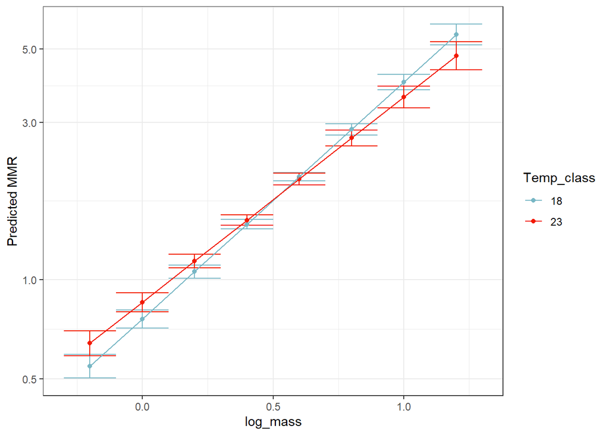

```r
# plot MMR vs. log mass mean predicted level

pred_MMR <- ggpredict(MMR_mod, terms = c("log_mass", "Temp_class"))

ggplot() +
  geom_errorbar(data = pred_MMR, aes(x=x, ymin = conf.low, ymax = conf.high, color = group, group = group), width = 0.2) +   # add error bars showing 95% confidence intervals
  geom_point(data = pred_MMR, aes(x = x, y = predicted, color = group, group = group)) +
  geom_line(data = pred_MMR, aes(x = x, y = predicted, color = group, group = group)) +
  labs(x = "log_mass", y = "Predicted MMR", color = "Temp_class") +
  theme_bw() +
  scale_color_manual(values = c("#78B7C5", "#F21A00")) +
  scale_y_log10()
```

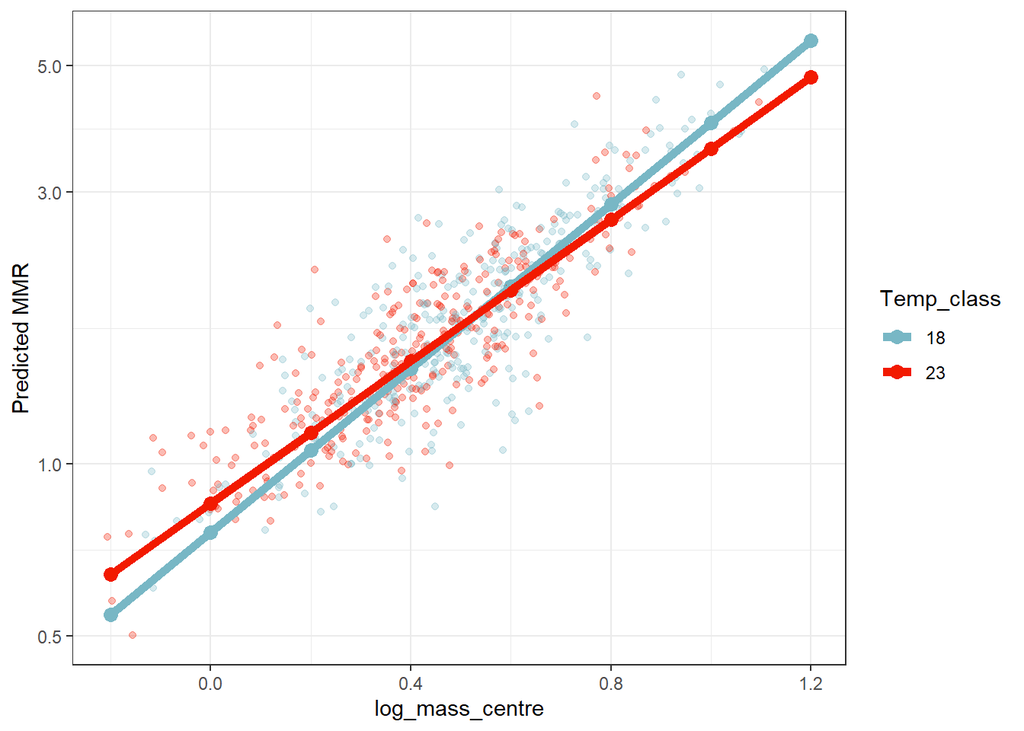

```r
# Plot the raw data as a cloud around the predictions
ggplot() +
  geom_point(data = ds1, aes(x = log_mass, y = MMR, group = factor(Temp_class), color = factor(Temp_class)),
             alpha = 0.3, position = position_jitter(width = 0.1)) +
  geom_point(data = pred_MMR, aes(x = x, y = predicted, color = group, group = group),
             size = 3) +
  geom_line(data = pred_MMR, aes(x = x, y = predicted, color = group, group = group),
            size = 2) +
  labs(x = "log_mass_centre", y = "Predicted MMR", color = "Temp_class") +
  theme_bw() +
  scale_color_manual(values = c("#78B7C5", "#F21A00")) +
  scale_y_log10()
```

```r
# F test on interaction effect

anova(MMR_mod, type = "3")
```

```
## Type III Analysis of Variance Table with Satterthwaite's method
##                                Sum Sq Mean Sq NumDF  DenDF   F value    Pr(>F)
## log_mass                       6.1674  6.1674     1 349.13 1453.5364 < 2.2e-16
## as.factor(Temp_class)          0.0296  0.0296     1 264.40    6.9784  0.008741
## Sex                            0.0367  0.0367     1  87.00    8.6421  0.004206
## Density                        0.0811  0.0811     1 211.71   19.1076 1.936e-05
## log_mass:as.factor(Temp_class) 0.0314  0.0314     1 359.55    7.4113  0.006797
##
## log_mass                       ***
## as.factor(Temp_class)          **
## Sex                            **
## Density                        ***
## log_mass:as.factor(Temp_class) **
## ---
## Signif. codes:  0 '***' 0.001 '**' 0.01 '*' 0.05 '.' 0.1 ' ' 1
```

```r
# Generate fitted data

z_MMR<-augment(MMR_mod)                             # get variables and fitted values from model
head(z_MMR)
```

```
## # A tibble: 6 × 18
##   .rownames `log10(MMR)` log_mass `as.factor(Temp_class)` Sex   Density ID_fish
##   <chr>            <dbl>    <dbl> <fct>                   <fct>   <dbl>   <dbl>
## 1 1               0.154    0.423  23                      F           8      81
## 2 2               0.0458  -0.0915 23                      M           8      82
## 3 3               0.159    0.250  23                      F           8      83
## 4 4               0.215    0.436  23                      M           8      84
## 5 5               0.227    0.360  23                      M           8      85
## 6 7               0.0919   0.310  23                      M           8      87
## # ℹ 11 more variables: .fitted <dbl>, .resid <dbl>, .hat <dbl>, .cooksd <dbl>,
## #   .fixed <dbl>, .mu <dbl>, .offset <dbl>, .sqrtXwt <dbl>, .sqrtrwt <dbl>,
## #   .weights <dbl>, .wtres <dbl>
```

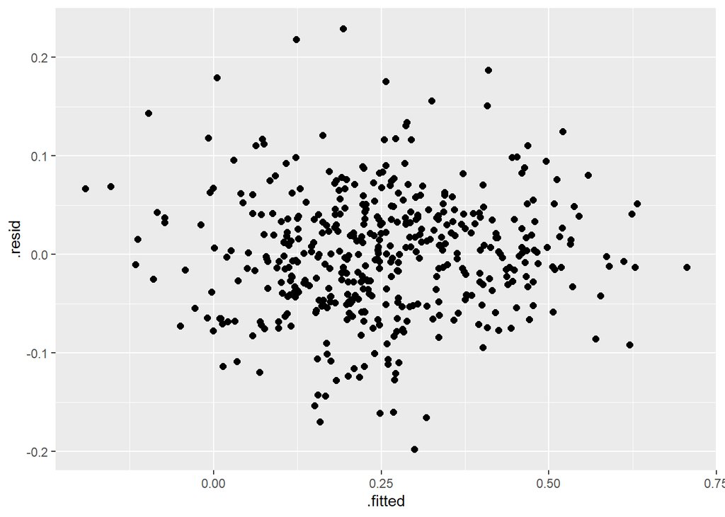

```r
z_MMR <- z_MMR %>%
  mutate(
    pwr.fitted = 10^(.fitted)
  )

# check assumptions: plot all residual values against the fitted
ggplot(z_MMR, aes(x = .fitted, y = .resid)) +       # same plot as before
  geom_point(size = 2)
```

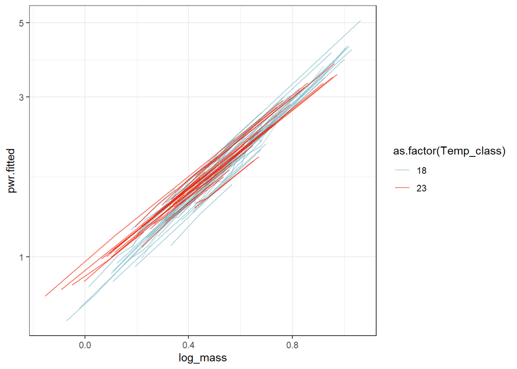

```r
ggplot(z_MMR, aes(x = log_mass, y = MMR, group = ID_fish)) +
  geom_line(aes(y = pwr.fitted, color = `as.factor(Temp_class)`),
            alpha = 0.6) +
  theme_bw() +
  scale_y_log10()+
  scale_color_manual(values  = c("#78B7C5", "#F21A00"))
```

# FIGURE 2

Generate a figure that displays mass-scaling relationships for all three metabolic rates at both temperatures

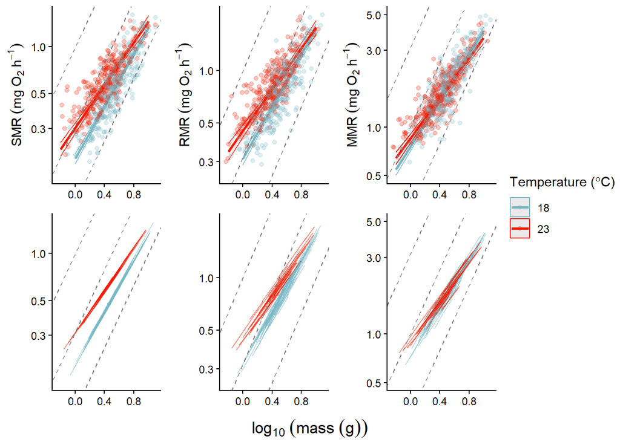

```r
### FIG. 2 ###

fig2.1 <- ggplot() +
    geom_ribbon(data = pred_SMR, aes(x=x, ymin = conf.low, ymax = conf.high, fill = group, color = group, group = group), width = 0.2, alpha = 0.1) +   # add error bars showing 95% confidence intervals
  geom_line(data = pred_SMR, aes(x = x, y = predicted, color = group, group = group),
            size = 1) +
  geom_point(data = ds1, aes(x = log_mass, y = SMR, group = factor(Temp_class), color = factor(Temp_class)),
             alpha = 0.25, position = position_jitter(width = 0.1)) +
  labs(x = "log10(mass (g))", y = expression(SMR~(mg~O[2]~h^-1)), color = expression("Temperature ("*degree*C*")")) +
  theme_classic() +
  ## --- add isometric scaling lines ---
  geom_abline(intercept = -1, slope = 1, linetype = "dashed", color = "grey50") +
  geom_abline(intercept = -0.5, slope = 1, linetype = "dashed", color = "grey50") +
  geom_abline(intercept = 0, slope = 1, linetype = "dashed", color = "grey50") +
  ## ------------------------------------
  scale_color_manual(values = c("#78B7C5", "#F21A00")) +
  scale_fill_manual(values = c("#78B7C5", "#F21A00"), guide = "none") +
  xlim(-0.25, 1.1) +
 scale_y_log10(limits = c(0.15, 1.6))

fig2.2 <- ggplot() +
    geom_ribbon(data = pred_RMR, aes(x=x, ymin = conf.low, ymax = conf.high, fill = group, color = group, group = group), width = 0.2, alpha = 0.1) +   # add error bars showing 95% confidence intervals
  geom_line(data = pred_RMR, aes(x = x, y = predicted, color = group, group = group),
            size = 1) +
  geom_point(data = ds1, aes(x = log_mass, y = RMR, group = factor(Temp_class), color = factor(Temp_class)),
             alpha = 0.25, position = position_jitter(width = 0.1)) +
  labs(x = "log10(mass (g))", y = expression(RMR~(mg~O[2]~h^-1)), color = expression("Temperature ("*degree*C*")")) +
  theme_classic() +
  ## --- add isometric scaling lines ---
  geom_abline(intercept = -1, slope = 1, linetype = "dashed", color = "grey50") +
  geom_abline(intercept = -0.5, slope = 1, linetype = "dashed", color = "grey50") +
  geom_abline(intercept = 0, slope = 1, linetype = "dashed", color = "grey50") +
  ## ------------------------------------
  scale_color_manual(values = c("#78B7C5", "#F21A00")) +
  scale_fill_manual(values = c("#78B7C5", "#F21A00"), guide = "none") +
  xlim(-0.25, 1.1) +
  scale_y_log10(limits=c(0.25,2.1))

fig2.3 <- ggplot() +
    geom_ribbon(data = pred_MMR, aes(x=x, ymin = conf.low, ymax = conf.high, fill = group, color = group, group = group), width = 0.2, alpha = 0.1) +   # add error bars showing 95% confidence intervals
  geom_line(data = pred_MMR, aes(x = x, y = predicted, color = group, group = group),
            size = 1) +
  geom_point(data = ds1, aes(x = log_mass, y = MMR, group = factor(Temp_class), color = factor(Temp_class)),
             alpha = 0.25, position = position_jitter(width = 0.1)) +
  labs(x = expression(log[10]~(mass~(g))), y = expression(MMR~(mg~O[2]~h^-1)), color = expression("Temperature ("*degree*C*")")) +
  theme_classic() +
   ## --- add isometric scaling lines ---
  geom_abline(intercept = -0.5, slope = 1, linetype = "dashed", color = "grey50") +
  geom_abline(intercept = 0, slope = 1, linetype = "dashed", color = "grey50") +
  geom_abline(intercept = 0.5, slope = 1, linetype = "dashed", color = "grey50") +
  ## ------------------------------------
  scale_color_manual(values = c("#78B7C5", "#F21A00")) +
  scale_fill_manual(values = c("#78B7C5", "#F21A00"), guide = "none") +
  xlim(-0.25, 1.1) +
  scale_y_log10(limits=c(0.5, 5))

fig2.4 <- ggplot(z_SMR, aes(x = log_mass, y = SMR, group = ID_fish)) +
  geom_line(aes(y = pwr.fitted, color = `as.factor(Temp_class)`),      # note this will look odd if there are additional fixed effects
            alpha = 0.6) +
  theme_classic() +
  ## --- add isometric scaling lines ---
  geom_abline(intercept = -1, slope = 1, linetype = "dashed", color = "grey50") +
  geom_abline(intercept = -0.5, slope = 1, linetype = "dashed", color = "grey50") +
  geom_abline(intercept = 0, slope = 1, linetype = "dashed", color = "grey50") +
  ## ------------------------------------
  scale_color_manual(values  = c("#78B7C5", "#F21A00")) +
  scale_y_log10(limits = c(0.15, 1.6))+
  xlim(-0.25, 1.1) +
  labs(x = expression(log[10]~(mass~(g))), y = expression(Fitted~SMR~(mg~O[2]~h^-1)), color = expression("Temperature ("*degree*C*")"))


fig2.5 <- ggplot(z_RMR, aes(x = log_mass, y = RMR, group = ID_fish)) +
  geom_line(aes(y = pwr.fitted, color = `as.factor(Temp_class)`),      # note this will look odd if there are additional fixed effects
            alpha = 0.6) +
  theme_classic() +
  ## --- add isometric scaling lines ---
  geom_abline(intercept = -1, slope = 1, linetype = "dashed", color = "grey50") +
  geom_abline(intercept = -0.5, slope = 1, linetype = "dashed", color = "grey50") +
  geom_abline(intercept = 0, slope = 1, linetype = "dashed", color = "grey50") +
  ## ------------------------------------
  scale_color_manual(values  = c("#78B7C5", "#F21A00")) +
  scale_y_log10(limits=c(0.25,2.1))+
  xlim(-0.25, 1.1) +
  labs(x = expression(log[10]~(mass~(g))), y = expression(Fitted~RMR~(mg~O[2]~h^-1)), color = expression("Temperature ("*degree*C*")"))

fig2.6 <- ggplot(z_MMR, aes(x = log_mass, y = MMR, group = ID_fish)) +
  geom_line(aes(y = pwr.fitted, color = `as.factor(Temp_class)`),      # note this will look odd if there are additional fixed effects
            alpha = 0.6) +
  theme_classic() +
  ## --- add isometric scaling lines ---
  geom_abline(intercept = -0.5, slope = 1, linetype = "dashed", color = "grey50") +
  geom_abline(intercept = 0, slope = 1, linetype = "dashed", color = "grey50") +
  geom_abline(intercept = 0.5, slope = 1, linetype = "dashed", color = "grey50") +
  ## ------------------------------------
  scale_color_manual(values  = c("#78B7C5", "#F21A00")) +
  scale_y_log10(limits=c(0.5, 5))+
  xlim(-0.25, 1.1) +
  labs(x = expression(log[10]~(mass~(g))), y = expression(Fitted~MMR~(mg~O[2]~h^-1)), color = expression("Temperature ("*degree*C*")"))

library(ggpubr)

fig2 <- ggarrange(print(fig2.1 + rremove("xlab")),
                  print(fig2.2 + rremove("xlab")),
                  print(fig2.3 + rremove("xlab")),
                  print(fig2.4 + rremove("xlab") + rremove("ylab")),
                  print(fig2.5 + rremove("xlab") + rremove("ylab")),
                  print(fig2.6 + rremove("xlab") + rremove("ylab")),
                           ncol = 3, nrow = 2, widths = c(5, 5, 5),
                           align = "v",
                           common.legend = TRUE,
                           legend = "right")

require(grid)
annotate_figure(fig2, bottom = textGrob(expression(log[10]~(mass~(g))), gp = gpar(cex = 1.1)))
```

```r
setwd(figures_wd)
jpeg(file = "Fig2.jpeg", width = 1440, height=960, units = "px")
annotate_figure(fig2, bottom = textGrob(expression(log[10]~(mass~(g))), gp = gpar(cex = 1.1)))
dev.off()
```

# UNIVARIATE MODEL OF FAT MASS

```r
#subset ds1 to only include fish for which fat mass was measured
ds_fat <- ds1[which(!is.na(ds1$log_fatmass) & ds1$Month == "September"),]

fat_mod <- lm(log_fatmass ~ Temp_class + log_finalmass_centre:Temp_class + Sex + Density, data=ds_fat)

fat_mod1 <- lm(log_fatmass ~ Temp_class + log_finalmass_centre:Temp_class + SMR:Temp_class + Sex + Density, data=ds_fat) #using only final measurement of SMR here

fat_mod2 <- lm(log_fatmass ~ Temp_class + log_finalmass_centre:Temp_class + RMR:Temp_class + Sex + Density, data=ds_fat) #using only final measurement of RMR here

fat_mod3 <- lm(log_fatmass ~ Temp_class + log_finalmass_centre:Temp_class + MMR:Temp_class + Sex + Density, data=ds_fat) #using only final measurement of MMR here

fat_mod_sexlinked <- lm(log_fatmass ~ Temp_class + log_finalmass_centre:Temp_class + Sex + Sex:Temp_class + Sex:log_finalmass_centre + Sex:Temp_class:log_finalmass_centre + Density, data=ds_fat)

summary(fat_mod)   # generate model output
```

```
##
## Call:
## lm(formula = log_fatmass ~ Temp_class + log_finalmass_centre:Temp_class +
##     Sex + Density, data = ds_fat)
##
## Residuals:
##     Min      1Q  Median      3Q     Max
## -0.8250 -0.0956  0.0355  0.1216  0.2995
##
## Coefficients:
##                                   Estimate Std. Error t value Pr(>|t|)
## (Intercept)                       -1.68579    0.13181 -12.790   <2e-16 ***
## Temp_class23                      -0.33809    0.13982  -2.418   0.0178 *
## SexM                              -0.01235    0.04276  -0.289   0.7734
## Density                           -0.01137    0.01388  -0.819   0.4150
## Temp_class18:log_finalmass_centre  1.62751    0.14871  10.944   <2e-16 ***
## Temp_class23:log_finalmass_centre  2.43030    0.19134  12.702   <2e-16 ***
## ---
## Signif. codes:  0 '***' 0.001 '**' 0.01 '*' 0.05 '.' 0.1 ' ' 1
##
## Residual standard error: 0.1868 on 84 degrees of freedom
##   (23 observations deleted due to missingness)
## Multiple R-squared:  0.7818, Adjusted R-squared:  0.7688
## F-statistic:  60.2 on 5 and 84 DF,  p-value: < 2.2e-16
```

```r
plot(fat_mod)      # residuals plot
```

```r
anova(fat_mod)
```

```
## Analysis of Variance Table
##
## Response: log_fatmass
##                                 Df  Sum Sq Mean Sq  F value  Pr(>F)
## Temp_class                       1  0.0406  0.0406   1.1621 0.28411
## Sex                              1  0.1974  0.1974   5.6565 0.01966 *
## Density                          1  0.0041  0.0041   0.1170 0.73315
## Temp_class:log_finalmass_centre  2 10.2619  5.1309 147.0427 < 2e-16 ***
## Residuals                       84  2.9311  0.0349
## ---
## Signif. codes:  0 '***' 0.001 '**' 0.01 '*' 0.05 '.' 0.1 ' ' 1
```

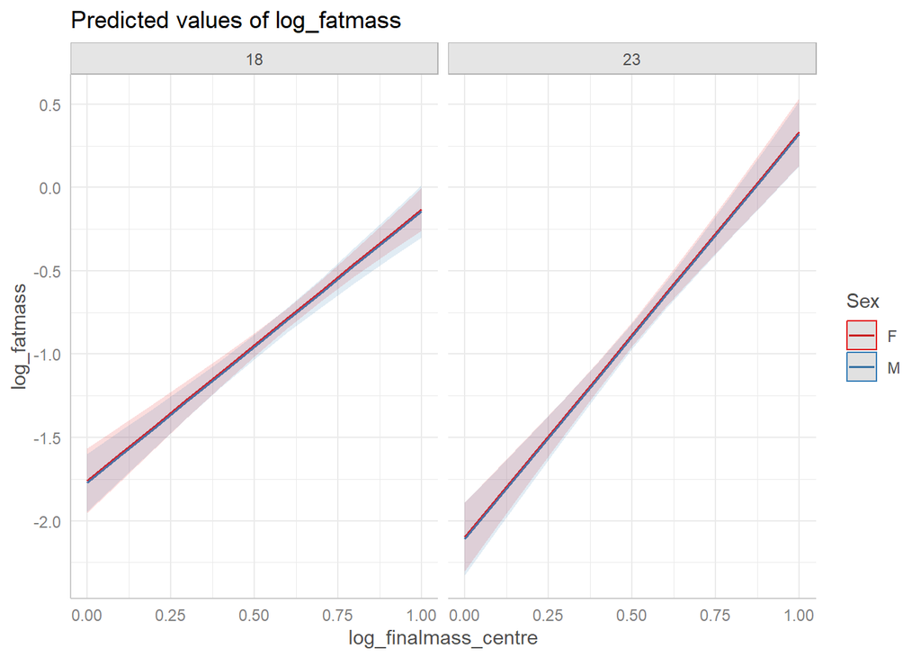

```r
#Marginal Effects
#Plotting marginal effects
require(ggeffects)
pred.fat_mod <- ggpredict(fat_mod, terms = c("log_finalmass_centre", "Sex", "Temp_class"))
plot(pred.fat_mod)
```

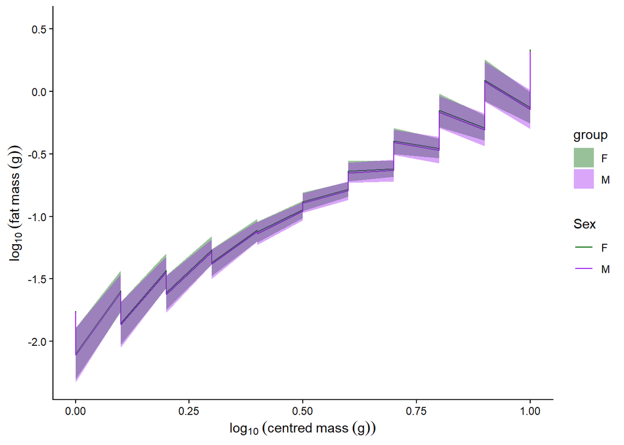

```r
ggplot() +
  geom_line(data = pred.fat_mod, aes(x = x, y = predicted, color = group, group = group)) +
  geom_ribbon(data = pred.fat_mod, aes(x= x, ymin = conf.low, ymax = conf.high, fill = group, group = group), alpha = 0.4) +
  labs(x = expression(log[10]~(centred~mass~(g))), y = expression(log[10]~(fat~mass~(g))), color = expression("Sex")) +
  theme_classic() +
  scale_color_manual(values = c("darkgreen", "purple")) +
  scale_fill_manual(values = c("darkgreen", "purple"))
```

```r
summary(fat_mod1)   # generate model output
```

```
##
## Call:
## lm(formula = log_fatmass ~ Temp_class + log_finalmass_centre:Temp_class +
##     SMR:Temp_class + Sex + Density, data = ds_fat)
##
## Residuals:
##      Min       1Q   Median       3Q      Max
## -0.75613 -0.09036  0.04041  0.12172  0.31448
##
## Coefficients:
##                                    Estimate Std. Error t value Pr(>|t|)
## (Intercept)                       -1.669290   0.132302 -12.617  < 2e-16 ***
## Temp_class23                      -0.335509   0.143164  -2.344   0.0215 *
## SexM                              -0.028106   0.045131  -0.623   0.5352
## Density                           -0.009403   0.014587  -0.645   0.5210
## Temp_class18:log_finalmass_centre  1.373244   0.306634   4.478 2.41e-05 ***
## Temp_class23:log_finalmass_centre  2.827861   0.397690   7.111 3.91e-10 ***
## Temp_class18:SMR                   0.136718   0.146222   0.935   0.3525
## Temp_class23:SMR                  -0.268150   0.236012  -1.136   0.2592
## ---
## Signif. codes:  0 '***' 0.001 '**' 0.01 '*' 0.05 '.' 0.1 ' ' 1
##
## Residual standard error: 0.1866 on 82 degrees of freedom
##   (23 observations deleted due to missingness)
## Multiple R-squared:  0.7876, Adjusted R-squared:  0.7694
## F-statistic: 43.43 on 7 and 82 DF,  p-value: < 2.2e-16
```

```r
plot(fat_mod)      # residuals plot
```

```r
summary(fat_mod2)   # generate model output
```

```
##
## Call:
## lm(formula = log_fatmass ~ Temp_class + log_finalmass_centre:Temp_class +
##     RMR:Temp_class + Sex + Density, data = ds_fat)
##
## Residuals:
##      Min       1Q   Median       3Q      Max
## -0.76919 -0.08987  0.04334  0.12239  0.30783
##
## Coefficients:
##                                   Estimate Std. Error t value Pr(>|t|)
## (Intercept)                       -1.67164    0.13345 -12.526  < 2e-16 ***
## Temp_class23                      -0.33243    0.14187  -2.343   0.0215 *
## SexM                              -0.02392    0.04425  -0.540   0.5904
## Density                           -0.01111    0.01425  -0.780   0.4379
## Temp_class18:log_finalmass_centre  1.40379    0.31899   4.401 3.22e-05 ***
## Temp_class23:log_finalmass_centre  2.74098    0.41355   6.628 3.35e-09 ***
## Temp_class18:RMR                   0.09706    0.12531   0.775   0.4409
## Temp_class23:RMR                  -0.15521    0.18365  -0.845   0.4005
## ---
## Signif. codes:  0 '***' 0.001 '**' 0.01 '*' 0.05 '.' 0.1 ' ' 1
##
## Residual standard error: 0.1876 on 82 degrees of freedom
##   (23 observations deleted due to missingness)
## Multiple R-squared:  0.7853, Adjusted R-squared:  0.7669
## F-statistic: 42.84 on 7 and 82 DF,  p-value: < 2.2e-16
```

```r
plot(fat_mod)      # residuals plot
```

```r
summary(fat_mod3)   # generate model output
```

```
##
## Call:
## lm(formula = log_fatmass ~ Temp_class + log_finalmass_centre:Temp_class +
##     MMR:Temp_class + Sex + Density, data = ds_fat)
##
## Residuals:
##      Min       1Q   Median       3Q      Max
## -0.75804 -0.09095  0.02879  0.12219  0.33877
##
## Coefficients:
##                                    Estimate Std. Error t value Pr(>|t|)
## (Intercept)                       -1.666135   0.133622 -12.469  < 2e-16 ***
## Temp_class23                      -0.320143   0.141473  -2.263   0.0263 *
## SexM                              -0.009131   0.042876  -0.213   0.8319
## Density                           -0.014221   0.014104  -1.008   0.3163
## Temp_class18:log_finalmass_centre  1.787541   0.296595   6.027 4.57e-08 ***
## Temp_class23:log_finalmass_centre  2.718573   0.301131   9.028 6.33e-14 ***
## Temp_class18:MMR                  -0.035603   0.058075  -0.613   0.5415
## Temp_class23:MMR                  -0.075744   0.061506  -1.231   0.2217
## ---
## Signif. codes:  0 '***' 0.001 '**' 0.01 '*' 0.05 '.' 0.1 ' ' 1
##
## Residual standard error: 0.1869 on 82 degrees of freedom
##   (23 observations deleted due to missingness)
## Multiple R-squared:  0.7867, Adjusted R-squared:  0.7685
## F-statistic: 43.21 on 7 and 82 DF,  p-value: < 2.2e-16
```

```r
plot(fat_mod)      # residuals plot
```

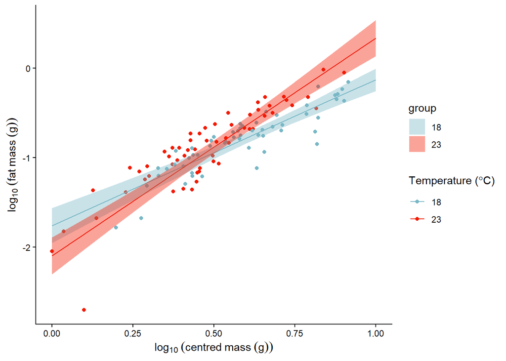

```r
pred_fat <- ggpredict(fat_mod, terms = c("log_finalmass_centre", "Temp_class"))

# Plot the raw data
ggplot() +
  geom_point(data = ds_fat, aes(x = log_finalmass_centre, y = log_fatmass, group = factor(Temp_class), color = factor(Temp_class))) +
  geom_line(data = pred_fat, aes(x = x, y = predicted, color = group, group = group)) +
  geom_ribbon(data = pred_fat, aes(x= x, ymin = conf.low, ymax = conf.high, fill = group, group = group), alpha = 0.4) +
  labs(x = expression(log[10]~(centred~mass~(g))), y = expression(log[10]~(fat~mass~(g))), color = expression("Temperature ("*degree*C*")")) +
  theme_classic() +
  scale_color_manual(values = c("#78B7C5", "#F21A00")) +
  scale_fill_manual(values = c("#78B7C5", "#F21A00"))
```

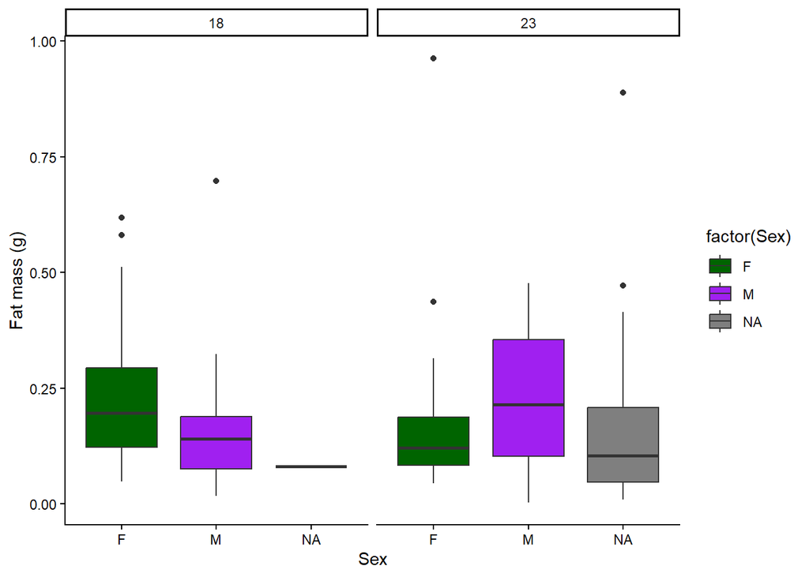

```r
ggplot(data = ds_fat, aes(y = Fat_mass_g, x = Sex, fill = factor(Sex))) +
  scale_fill_manual(values = c("darkgreen", "purple")) +
  geom_boxplot() +
  labs(x = "Sex", y = "Fat mass (g)") +
  theme_classic() +
  facet_grid(.~Temp_class)
```

```r
# F test on interaction term
anova(fat_mod)
```

```
## Analysis of Variance Table
##
## Response: log_fatmass
##                                 Df  Sum Sq Mean Sq  F value  Pr(>F)
## Temp_class                       1  0.0406  0.0406   1.1621 0.28411
## Sex                              1  0.1974  0.1974   5.6565 0.01966 *
## Density                          1  0.0041  0.0041   0.1170 0.73315
## Temp_class:log_finalmass_centre  2 10.2619  5.1309 147.0427 < 2e-16 ***
## Residuals                       84  2.9311  0.0349
## ---
## Signif. codes:  0 '***' 0.001 '**' 0.01 '*' 0.05 '.' 0.1 ' ' 1
```

```r
anova(fat_mod1)
```

```
## Analysis of Variance Table
##
## Response: log_fatmass
##                                 Df  Sum Sq Mean Sq  F value  Pr(>F)
## Temp_class                       1  0.0406  0.0406   1.1650 0.28359
## Sex                              1  0.1974  0.1974   5.6706 0.01957 *
## Density                          1  0.0041  0.0041   0.1173 0.73285
## Temp_class:log_finalmass_centre  2 10.2619  5.1309 147.4086 < 2e-16 ***
## Temp_class:SMR                   2  0.0769  0.0384   1.1045 0.33625
## Residuals                       82  2.8542  0.0348
## ---
## Signif. codes:  0 '***' 0.001 '**' 0.01 '*' 0.05 '.' 0.1 ' ' 1
```

```r
anova(fat_mod2)
```

```
## Analysis of Variance Table
##
## Response: log_fatmass
##                                 Df  Sum Sq Mean Sq  F value  Pr(>F)
## Temp_class                       1  0.0406  0.0406   1.1526 0.28616
## Sex                              1  0.1974  0.1974   5.6100 0.02021 *
## Density                          1  0.0041  0.0041   0.1161 0.73423
## Temp_class:log_finalmass_centre  2 10.2619  5.1309 145.8320 < 2e-16 ***
## Temp_class:RMR                   2  0.0460  0.0230   0.6542 0.52257
## Residuals                       82  2.8851  0.0352
## ---
## Signif. codes:  0 '***' 0.001 '**' 0.01 '*' 0.05 '.' 0.1 ' ' 1
```

```r
anova(fat_mod3)
```

```
## Analysis of Variance Table
##
## Response: log_fatmass
##                                 Df  Sum Sq Mean Sq  F value  Pr(>F)
## Temp_class                       1  0.0406  0.0406   1.1604 0.28455
## Sex                              1  0.1974  0.1974   5.6480 0.01981 *
## Density                          1  0.0041  0.0041   0.1168 0.73337
## Temp_class:log_finalmass_centre  2 10.2619  5.1309 146.8201 < 2e-16 ***
## Temp_class:MMR                   2  0.0654  0.0327   0.9364 0.39619
## Residuals                       82  2.8657  0.0349
## ---
## Signif. codes:  0 '***' 0.001 '**' 0.01 '*' 0.05 '.' 0.1 ' ' 1
```

```r
anova(fat_mod_sexlinked)
```

```
## Analysis of Variance Table
##
## Response: log_fatmass
##                                     Df  Sum Sq Mean Sq  F value  Pr(>F)
## Temp_class                           1  0.0406  0.0406   1.2668 0.26369
## Sex                                  1  0.1974  0.1974   6.1662 0.01509 *
## Density                              1  0.0041  0.0041   0.1276 0.72191
## Temp_class:log_finalmass_centre      2 10.2619  5.1309 160.2910 < 2e-16 ***
## Temp_class:Sex                       1  0.1291  0.1291   4.0341 0.04792 *
## log_finalmass_centre:Sex             1  0.2090  0.2090   6.5304 0.01247 *
## Temp_class:log_finalmass_centre:Sex  1  0.0001  0.0001   0.0037 0.95133
## Residuals                           81  2.5928  0.0320
## ---
## Signif. codes:  0 '***' 0.001 '**' 0.01 '*' 0.05 '.' 0.1 ' ' 1
```

## additional fat mass models to test alternative predictions:

### Prediction 1: Individual fat mass is the product of cumulative metabolic performance over time, not just a single point.

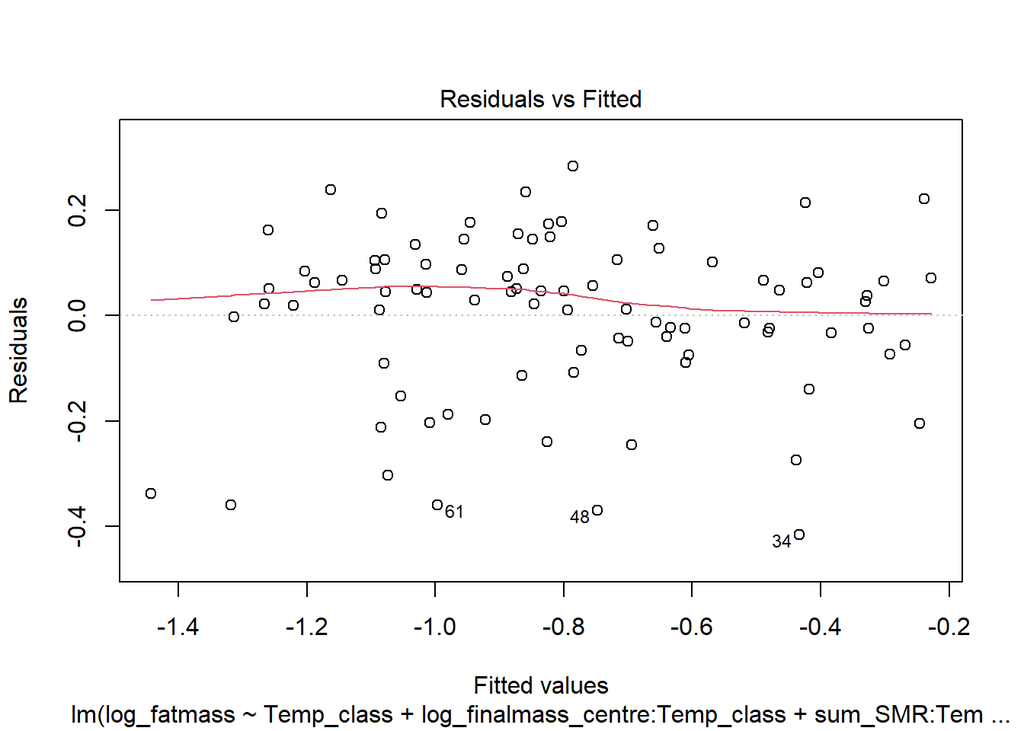

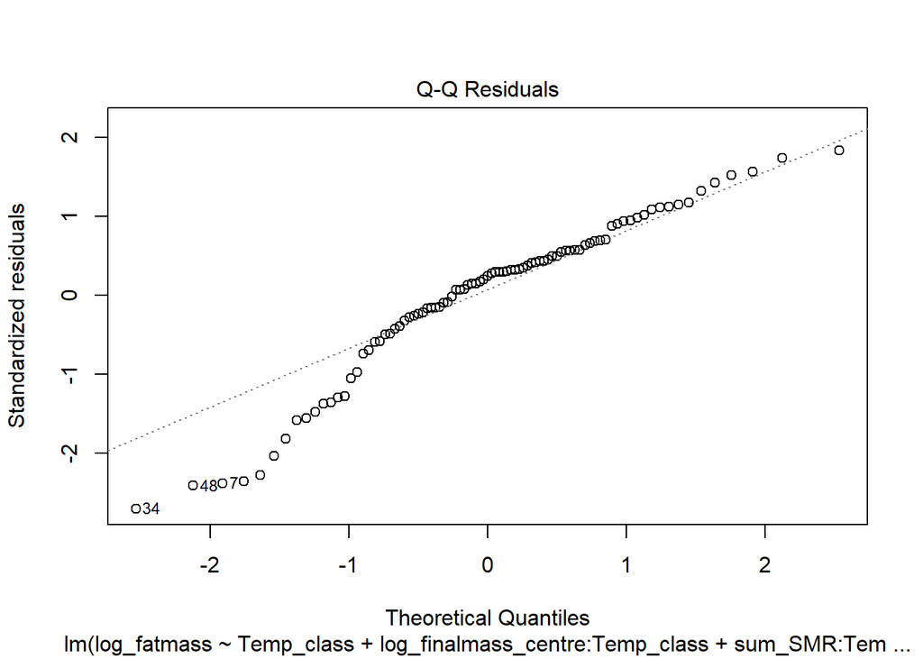

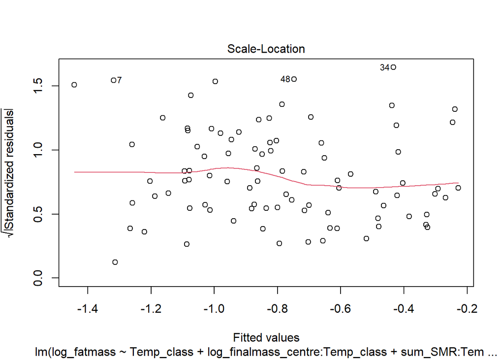

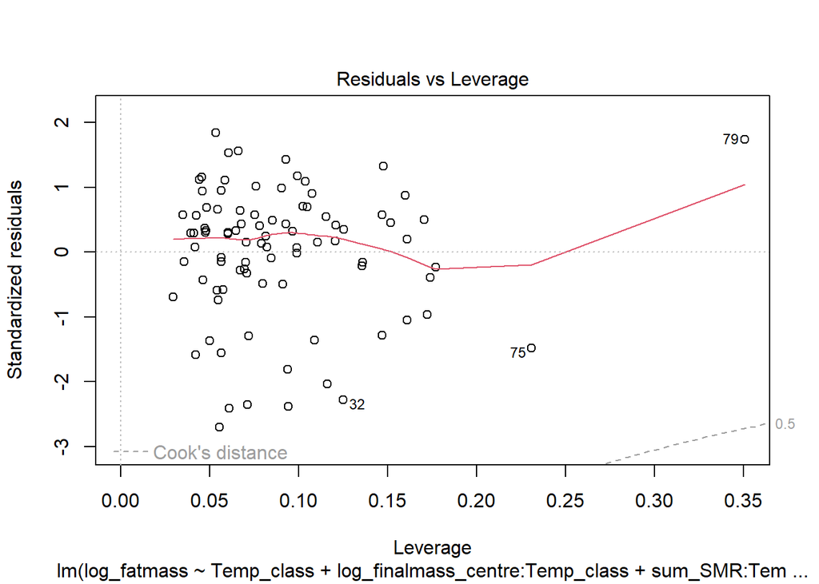

```r
# first step: add six new summary variables to ds_fat

ds_fat2 <- ds1 %>%
  group_by(ID_fish, Temp_class, Sex, Fat_mass_g, log_fatmass, log_finalmass_centre, finalmass_centre, Final_Mass_g) %>%
  summarise(
    sum_SMR = sum(SMR, na.rm = TRUE),
    mean_SMR = mean(SMR, na.rm = TRUE),
    sum_RMR = sum(RMR, na.rm = TRUE),
    mean_RMR = mean(RMR, na.rm = TRUE),
    sum_MMR = sum(MMR, na.rm = TRUE),
    mean_MMR = mean(MMR, na.rm = TRUE)
  ) %>% drop_na()

density <- ds1[which(ds1$Month == "September"),] %>% dplyr::select(ID_fish, Density)

ds_fat2 <- left_join(ds_fat2, density, by = c("ID_fish"))

ds_fat2 <- ds_fat2[which(ds_fat2$ID_fish != 99),] #Fish 99 is a clear outlier in the diagnostic plots. I have tested these models with and without it, and the results WRT the interaction terms between temperature:metabolism are unchanged.

# now we build the new models.
    # sum of metabolic trait models:

fat_mod_sumSMR <- lm(log_fatmass ~ Temp_class + log_finalmass_centre:Temp_class + sum_SMR:Temp_class + Sex + Density, data=ds_fat2)

fat_mod_sumRMR <- lm(log_fatmass ~ Temp_class + log_finalmass_centre:Temp_class + sum_RMR:Temp_class + Sex + Density, data=ds_fat2)

fat_mod_sumMMR <- lm(log_fatmass ~ Temp_class + log_finalmass_centre:Temp_class + sum_MMR:Temp_class + Sex + Density, data=ds_fat2)

    # mean of metabolic trait models:

fat_mod_meanSMR <- lm(log_fatmass ~ Temp_class + log_finalmass_centre:Temp_class + mean_SMR:Temp_class + Sex + Density, data=ds_fat2)

fat_mod_meanRMR <- lm(log_fatmass ~ Temp_class + log_finalmass_centre:Temp_class + mean_RMR:Temp_class + Sex + Density, data=ds_fat2)

fat_mod_meanMMR <- lm(log_fatmass ~ Temp_class + log_finalmass_centre:Temp_class + mean_MMR:Temp_class + Sex + Density, data=ds_fat2)

# finally, we test those models using the summary function.

plot(fat_mod_sumSMR)
```

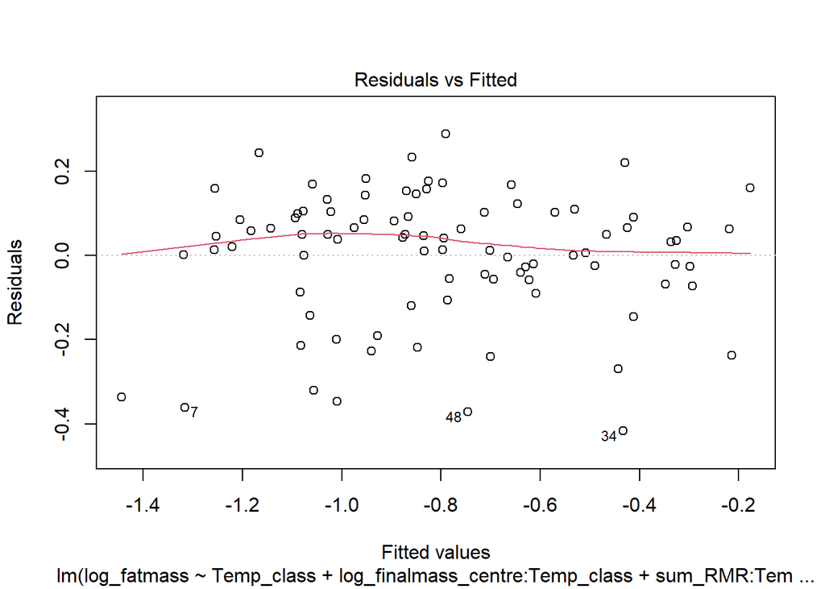

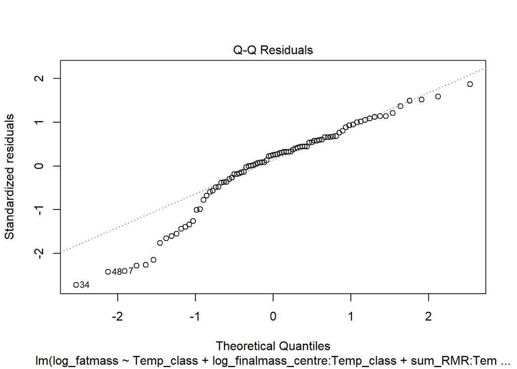

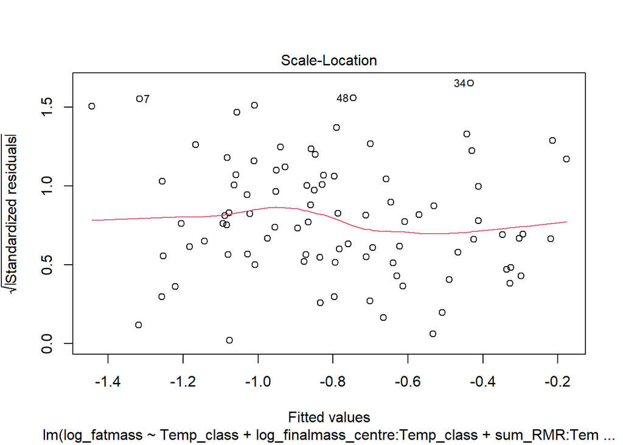

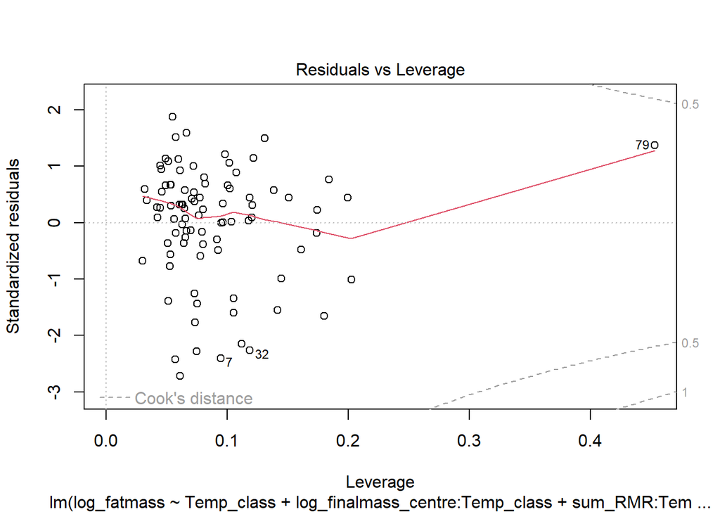

```r
plot(fat_mod_sumRMR)
```

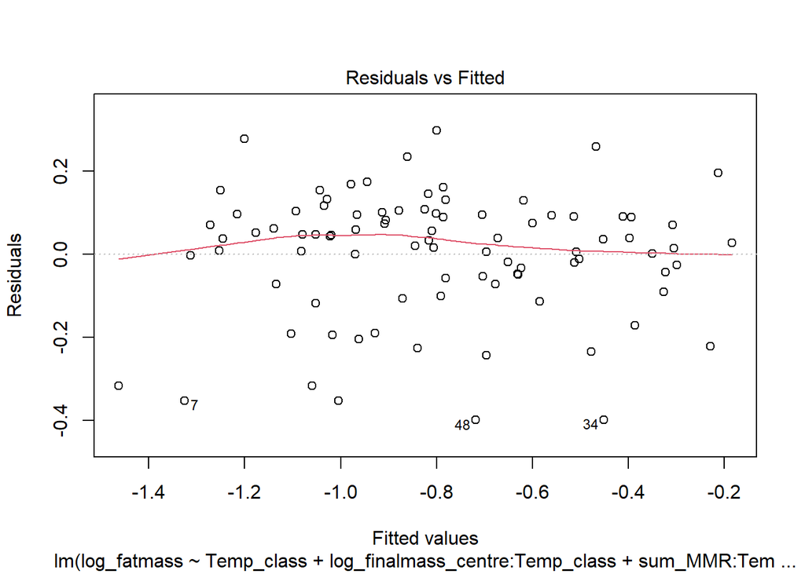

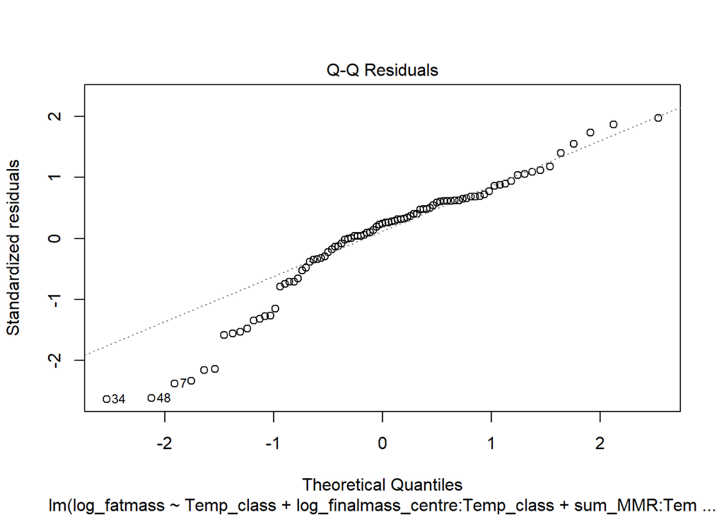

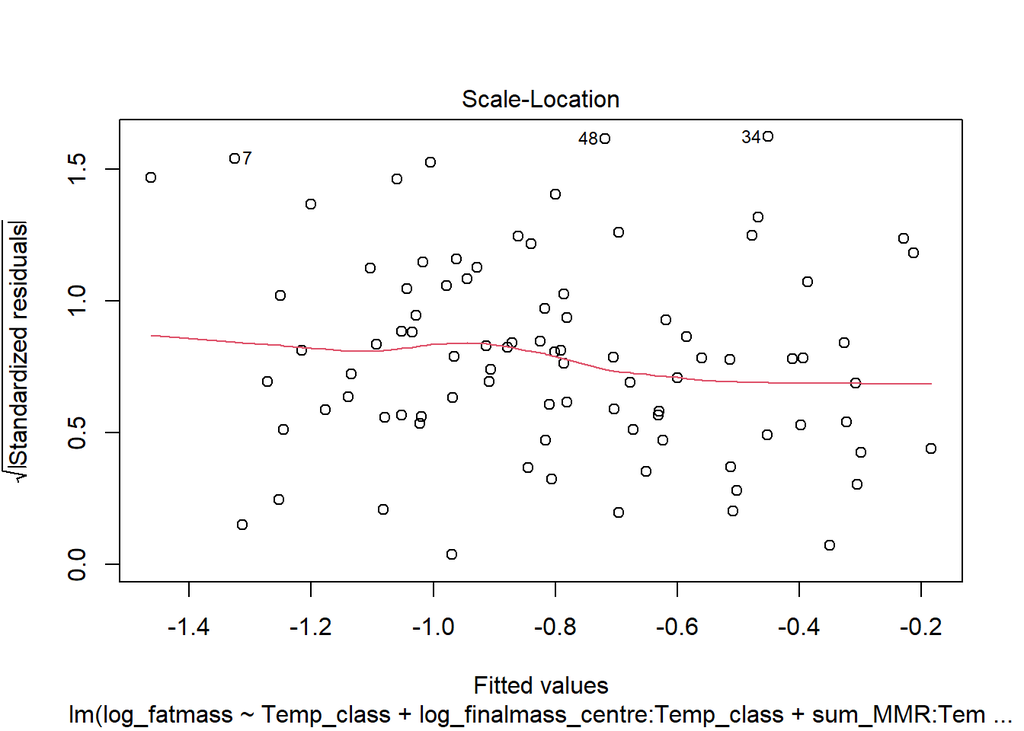

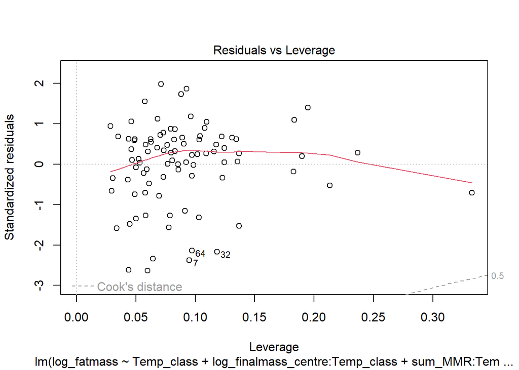

```r
plot(fat_mod_sumMMR)
```

```r
summary(fat_mod_sumSMR)
```

```
##
## Call:
## lm(formula = log_fatmass ~ Temp_class + log_finalmass_centre:Temp_class +
##     sum_SMR:Temp_class + Sex + Density, data = ds_fat2)
##
## Residuals:
##      Min       1Q   Median       3Q      Max
## -0.41645 -0.06632  0.03730  0.08871  0.28343
##
## Coefficients:
##                                    Estimate Std. Error t value Pr(>|t|)
## (Intercept)                       -1.770676   0.114306 -15.491  < 2e-16 ***
## Temp_class23                      -0.019339   0.130782  -0.148    0.883
## SexM                               0.028388   0.037671   0.754    0.453
## Density                           -0.005041   0.011825  -0.426    0.671
## Temp_class18:log_finalmass_centre  1.651272   0.260999   6.327 1.30e-08 ***
## Temp_class23:log_finalmass_centre  2.024549   0.362565   5.584 3.05e-07 ***
## Temp_class18:sum_SMR               0.005446   0.050609   0.108    0.915
## Temp_class23:sum_SMR              -0.015982   0.052470  -0.305    0.761
## ---
## Signif. codes:  0 '***' 0.001 '**' 0.01 '*' 0.05 '.' 0.1 ' ' 1
##
## Residual standard error: 0.1582 on 81 degrees of freedom
## Multiple R-squared:  0.7941, Adjusted R-squared:  0.7763
## F-statistic: 44.64 on 7 and 81 DF,  p-value: < 2.2e-16
```

```r
summary(fat_mod_sumRMR)
```

```
##
## Call:
## lm(formula = log_fatmass ~ Temp_class + log_finalmass_centre:Temp_class +
##     sum_RMR:Temp_class + Sex + Density, data = ds_fat2)
##
## Residuals:
##      Min       1Q   Median       3Q      Max
## -0.41715 -0.05773  0.03810  0.09891  0.28821
##
## Coefficients:
##                                     Estimate Std. Error t value Pr(>|t|)
## (Intercept)                       -1.7766622  0.1153979 -15.396  < 2e-16 ***
## Temp_class23                      -0.0290889  0.1316420  -0.221    0.826
## SexM                               0.0356420  0.0381283   0.935    0.353
## Density                           -0.0048447  0.0118045  -0.410    0.683
## Temp_class18:log_finalmass_centre  1.6890342  0.2179871   7.748 2.35e-11 ***
## Temp_class23:log_finalmass_centre  1.7631018  0.3726777   4.731 9.33e-06 ***
## Temp_class18:sum_RMR              -0.0009489  0.0302566  -0.031    0.975
## Temp_class23:sum_RMR               0.0208616  0.0409120   0.510    0.611
## ---
## Signif. codes:  0 '***' 0.001 '**' 0.01 '*' 0.05 '.' 0.1 ' ' 1
##
## Residual standard error: 0.1581 on 81 degrees of freedom
## Multiple R-squared:  0.7945, Adjusted R-squared:  0.7768
## F-statistic: 44.75 on 7 and 81 DF,  p-value: < 2.2e-16
```

```r
summary(fat_mod_sumMMR)
```

```
##
## Call:
## lm(formula = log_fatmass ~ Temp_class + log_finalmass_centre:Temp_class +
##     sum_MMR:Temp_class + Sex + Density, data = ds_fat2)
##
## Residuals:
##      Min       1Q   Median       3Q      Max
## -0.39970 -0.05819  0.03588  0.09449  0.29788
##
## Coefficients:
##                                    Estimate Std. Error t value Pr(>|t|)
## (Intercept)                       -1.738781   0.114786 -15.148  < 2e-16 ***
## Temp_class23                      -0.077190   0.133636  -0.578    0.565
## SexM                               0.037024   0.036718   1.008    0.316
## Density                           -0.004432   0.011717  -0.378    0.706
## Temp_class18:log_finalmass_centre  1.959238   0.231747   8.454 9.54e-13 ***
## Temp_class23:log_finalmass_centre  1.762639   0.350492   5.029 2.91e-06 ***
## Temp_class18:sum_MMR              -0.020543   0.014382  -1.428    0.157
## Temp_class23:sum_MMR               0.011203   0.020829   0.538    0.592
## ---
## Signif. codes:  0 '***' 0.001 '**' 0.01 '*' 0.05 '.' 0.1 ' ' 1
##
## Residual standard error: 0.1561 on 81 degrees of freedom
## Multiple R-squared:  0.7996, Adjusted R-squared:  0.7823
## F-statistic: 46.17 on 7 and 81 DF,  p-value: < 2.2e-16
```

```r
anova(fat_mod_sumSMR)
```

```
## Analysis of Variance Table
##
## Response: log_fatmass
##                                 Df Sum Sq Mean Sq  F value Pr(>F)
## Temp_class                       1 0.0020  0.0020   0.0800 0.7781
## Sex                              1 0.0523  0.0523   2.0906 0.1521
## Density                          1 0.0120  0.0120   0.4792 0.4907
## Temp_class:log_finalmass_centre  2 7.7549  3.8774 154.8538 <2e-16 ***
## Temp_class:sum_SMR               2 0.0026  0.0013   0.0516 0.9497
## Residuals                       81 2.0282  0.0250
## ---
## Signif. codes:  0 '***' 0.001 '**' 0.01 '*' 0.05 '.' 0.1 ' ' 1
```

```r
anova(fat_mod_sumRMR)
```

```
## Analysis of Variance Table
##
## Response: log_fatmass
##                                 Df Sum Sq Mean Sq  F value Pr(>F)
## Temp_class                       1 0.0020  0.0020   0.0801 0.7779
## Sex                              1 0.0523  0.0523   2.0947 0.1517
## Density                          1 0.0120  0.0120   0.4802 0.4903
## Temp_class:log_finalmass_centre  2 7.7549  3.8774 155.1549 <2e-16 ***
## Temp_class:sum_RMR               2 0.0065  0.0033   0.1305 0.8779
## Residuals                       81 2.0243  0.0250
## ---
## Signif. codes:  0 '***' 0.001 '**' 0.01 '*' 0.05 '.' 0.1 ' ' 1
```

```r
anova(fat_mod_sumMMR)
```

```
## Analysis of Variance Table
##
## Response: log_fatmass
##                                 Df Sum Sq Mean Sq  F value Pr(>F)
## Temp_class                       1 0.0020  0.0020   0.0821 0.7752
## Sex                              1 0.0523  0.0523   2.1477 0.1467
## Density                          1 0.0120  0.0120   0.4923 0.4849
## Temp_class:log_finalmass_centre  2 7.7549  3.8774 159.0816 <2e-16 ***
## Temp_class:sum_MMR               2 0.0565  0.0282   1.1588 0.3190
## Residuals                       81 1.9743  0.0244
## ---
## Signif. codes:  0 '***' 0.001 '**' 0.01 '*' 0.05 '.' 0.1 ' ' 1
```

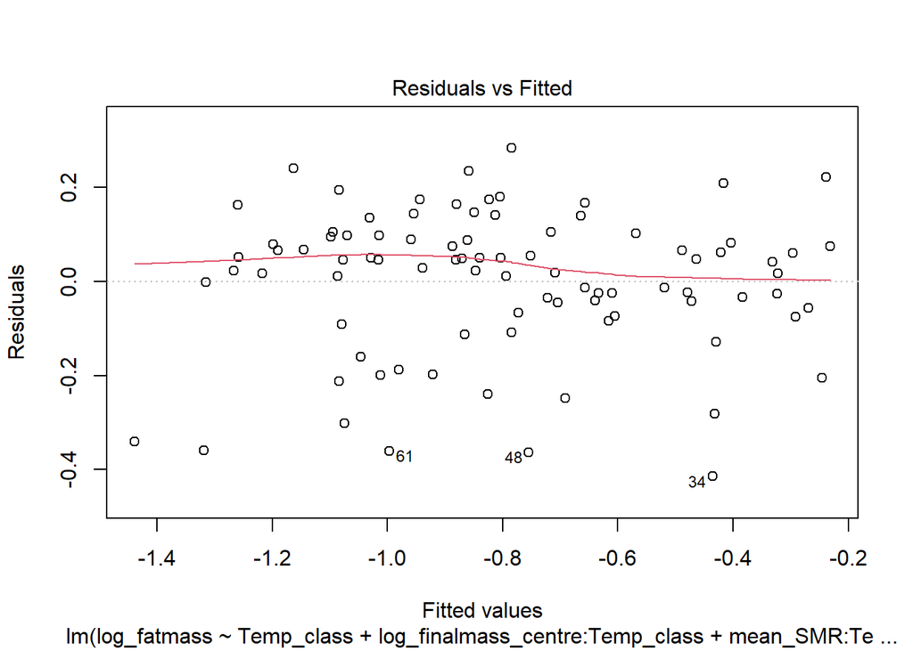

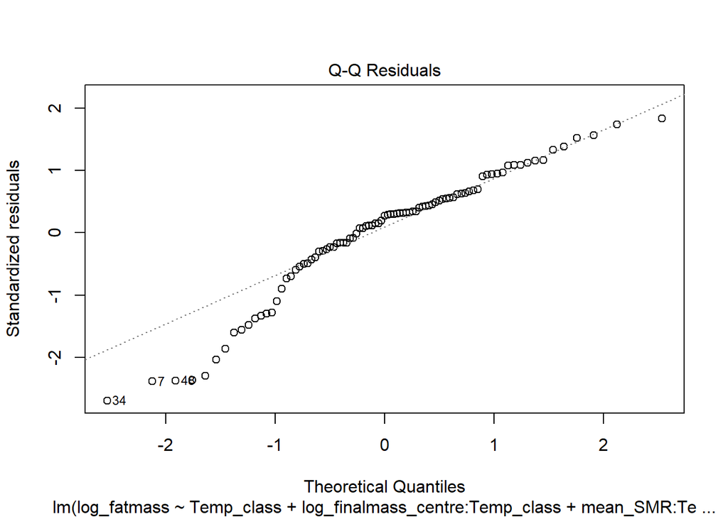

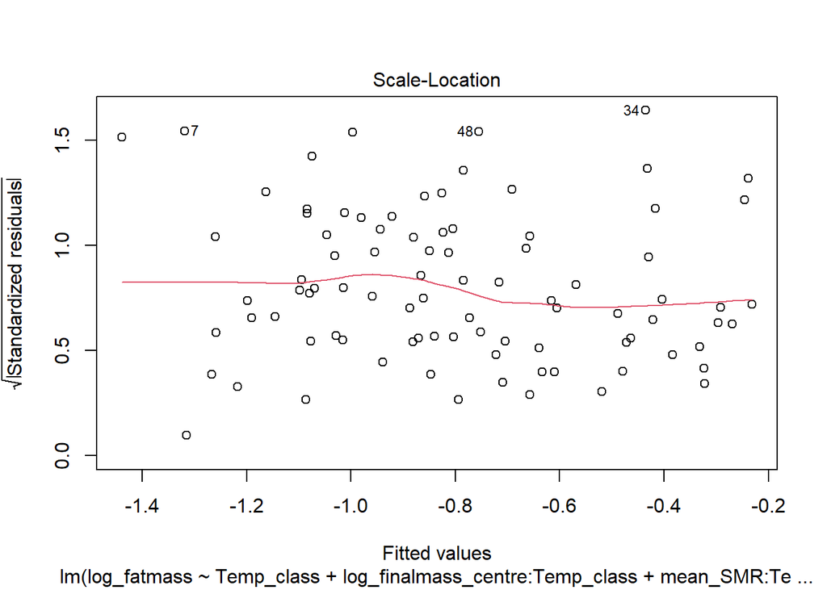

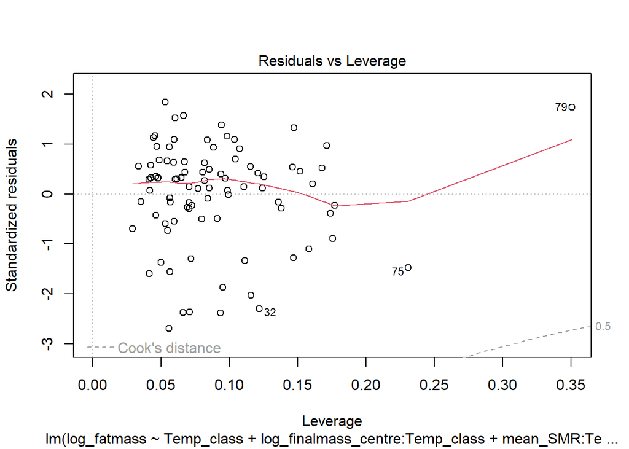

```r
plot(fat_mod_meanSMR)
```

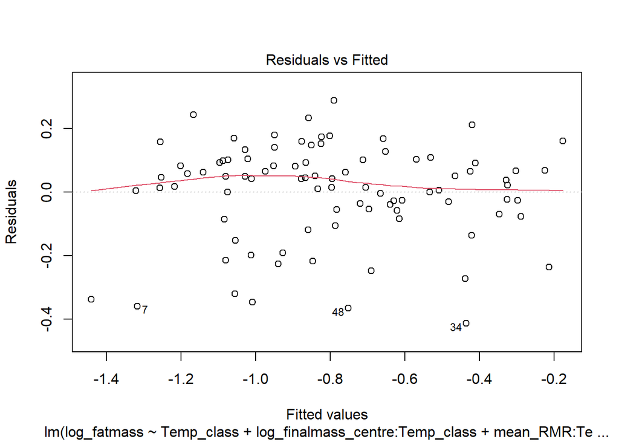

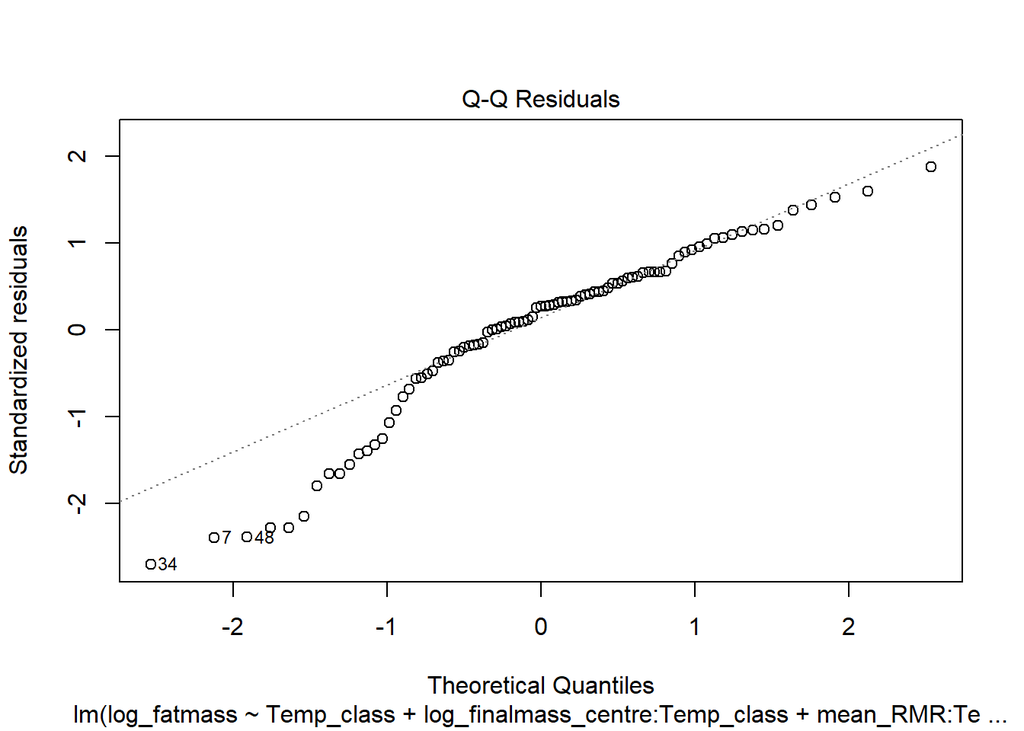

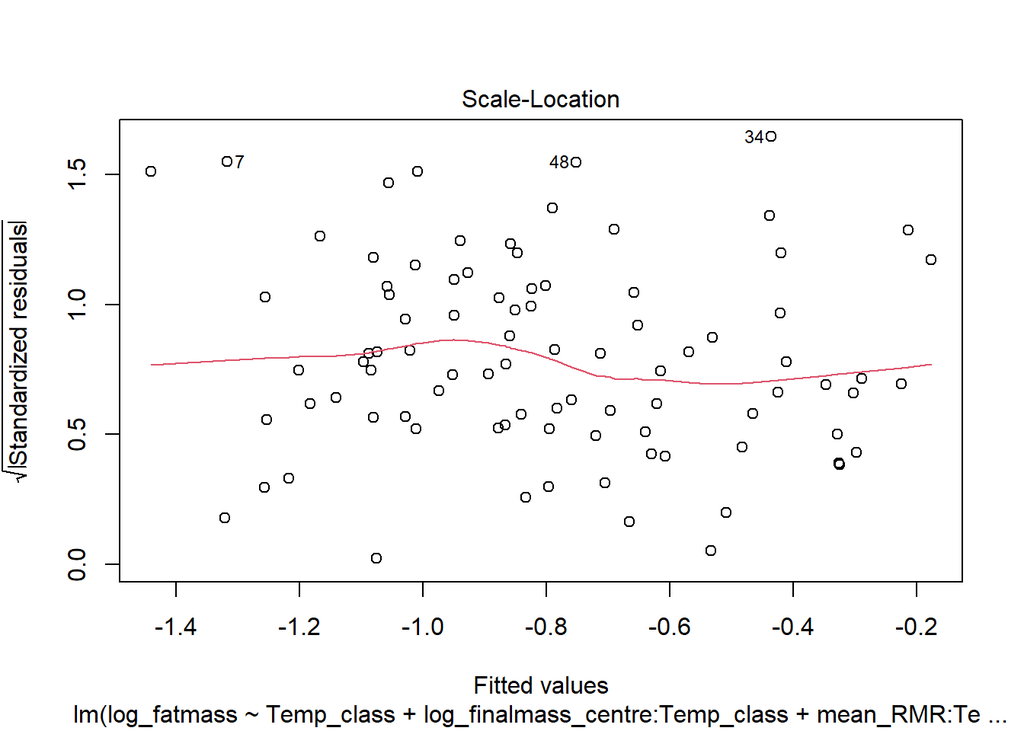

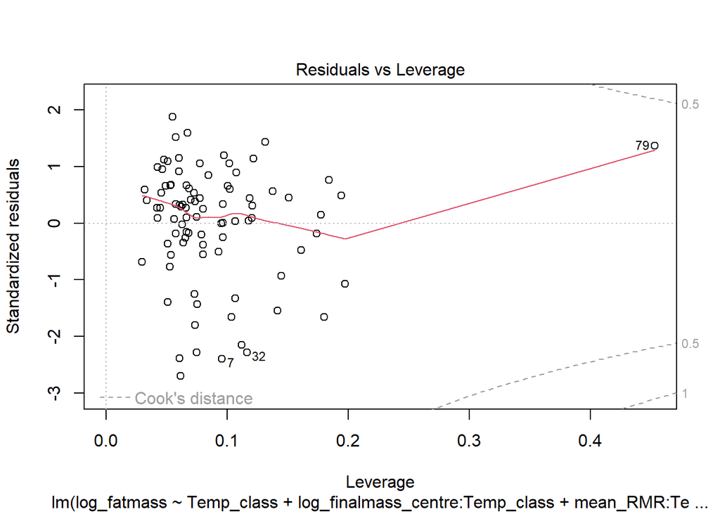

```r
plot(fat_mod_meanRMR)
```

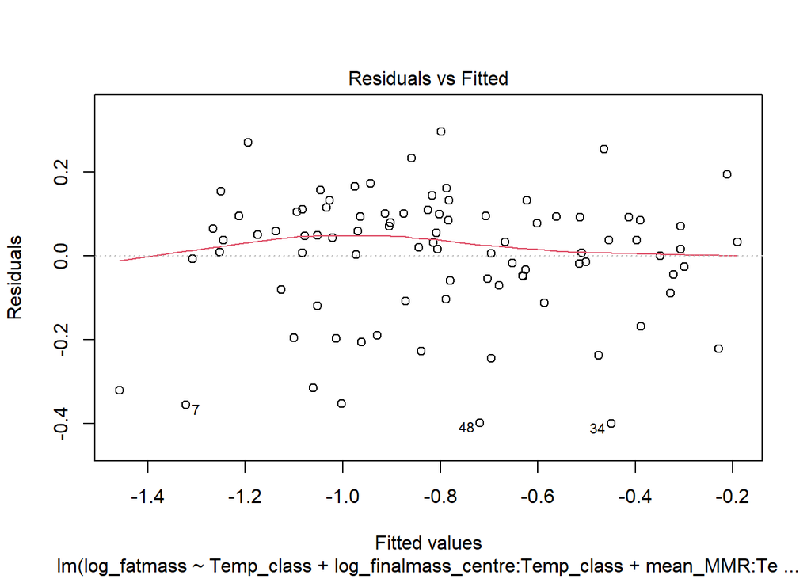

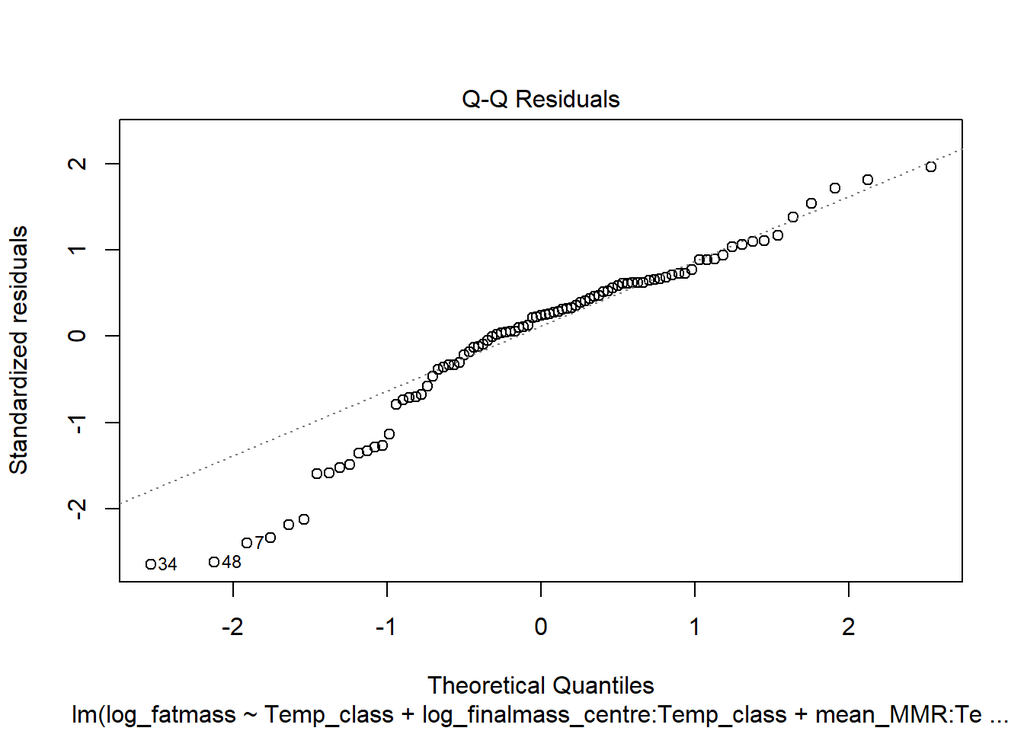

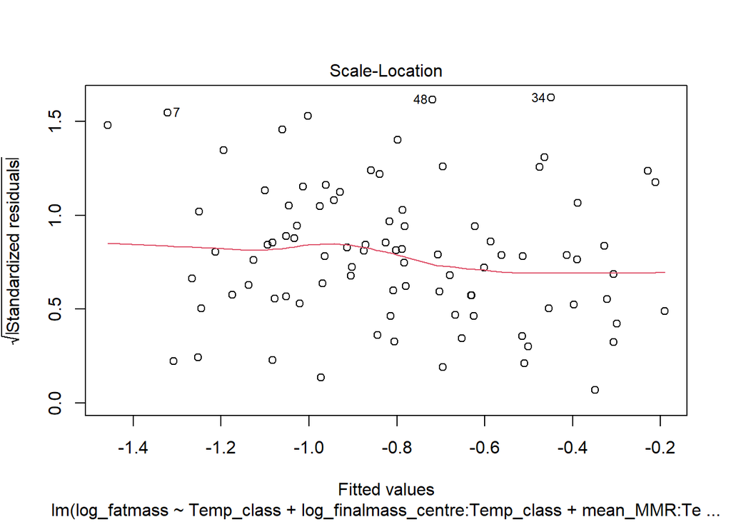

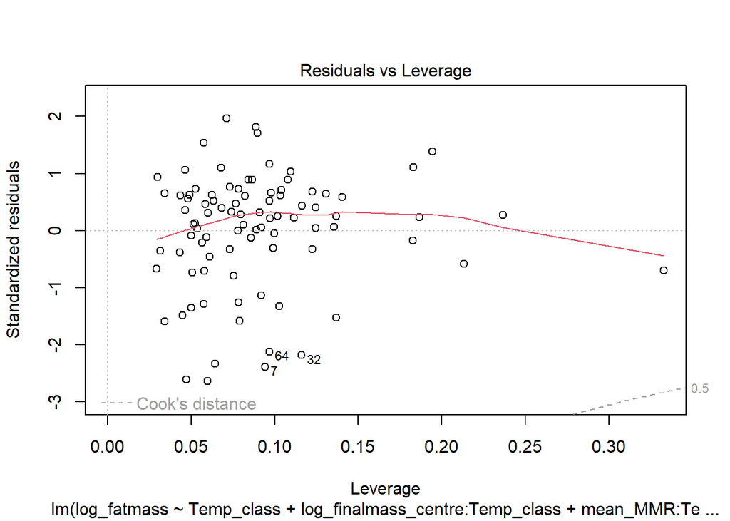

```r
plot(fat_mod_meanMMR)
```

```r
summary(fat_mod_meanSMR)
```

```
##
## Call:
## lm(formula = log_fatmass ~ Temp_class + log_finalmass_centre:Temp_class +
##     mean_SMR:Temp_class + Sex + Density, data = ds_fat2)
##
## Residuals:
##      Min       1Q   Median       3Q      Max
## -0.41459 -0.06653  0.04086  0.09415  0.28315
##
## Coefficients:
##                                    Estimate Std. Error t value Pr(>|t|)
## (Intercept)                       -1.776219   0.115055 -15.438  < 2e-16 ***
## Temp_class23                      -0.014237   0.131458  -0.108    0.914
## SexM                               0.028040   0.037522   0.747    0.457
## Density                           -0.004958   0.011809  -0.420    0.676
## Temp_class18:log_finalmass_centre  1.601795   0.260005   6.161 2.66e-08 ***
## Temp_class23:log_finalmass_centre  2.025166   0.362302   5.590 2.97e-07 ***
## Temp_class18:mean_SMR              0.084368   0.258901   0.326    0.745
## Temp_class23:mean_SMR             -0.080307   0.262172  -0.306    0.760
## ---
## Signif. codes:  0 '***' 0.001 '**' 0.01 '*' 0.05 '.' 0.1 ' ' 1
##
## Residual standard error: 0.1581 on 81 degrees of freedom
## Multiple R-squared:  0.7944, Adjusted R-squared:  0.7766
## F-statistic:  44.7 on 7 and 81 DF,  p-value: < 2.2e-16
```

```r
summary(fat_mod_meanRMR)
```

```
##
## Call:
## lm(formula = log_fatmass ~ Temp_class + log_finalmass_centre:Temp_class +
##     mean_RMR:Temp_class + Sex + Density, data = ds_fat2)
##
## Residuals:
##      Min       1Q   Median       3Q      Max
## -0.41417 -0.05789  0.04177  0.09868  0.28840
##
## Coefficients:
##                                    Estimate Std. Error t value Pr(>|t|)
## (Intercept)                       -1.781975   0.116214 -15.334  < 2e-16 ***
## Temp_class23                      -0.023554   0.132557  -0.178    0.859
## SexM                               0.035898   0.038150   0.941    0.350
## Density                           -0.004889   0.011805  -0.414    0.680
## Temp_class18:log_finalmass_centre  1.653298   0.214327   7.714 2.74e-11 ***
## Temp_class23:log_finalmass_centre  1.762469   0.372628   4.730 9.37e-06 ***
## Temp_class18:mean_RMR              0.026604   0.152512   0.174    0.862
## Temp_class23:mean_RMR              0.104621   0.204531   0.512    0.610
## ---
## Signif. codes:  0 '***' 0.001 '**' 0.01 '*' 0.05 '.' 0.1 ' ' 1
##
## Residual standard error: 0.1581 on 81 degrees of freedom
## Multiple R-squared:  0.7946, Adjusted R-squared:  0.7769
## F-statistic: 44.77 on 7 and 81 DF,  p-value: < 2.2e-16
```

```r
summary(fat_mod_meanMMR)
```

```
##
## Call:
## lm(formula = log_fatmass ~ Temp_class + log_finalmass_centre:Temp_class +
##     mean_MMR:Temp_class + Sex + Density, data = ds_fat2)
##
## Residuals:
##      Min       1Q   Median       3Q      Max
## -0.40115 -0.05938  0.03365  0.09427  0.29639
##
## Coefficients:
##                                    Estimate Std. Error t value Pr(>|t|)
## (Intercept)                       -1.737134   0.116268 -14.941  < 2e-16 ***
## Temp_class23                      -0.080236   0.135267  -0.593    0.555
## SexM                               0.034764   0.036721   0.947    0.347
## Density                           -0.004179   0.011750  -0.356    0.723
## Temp_class18:log_finalmass_centre  1.929046   0.233128   8.275 2.16e-12 ***
## Temp_class23:log_finalmass_centre  1.765246   0.351408   5.023 2.97e-06 ***
## Temp_class18:mean_MMR             -0.094372   0.074625  -1.265    0.210
## Temp_class23:mean_MMR              0.055682   0.104421   0.533    0.595
## ---
## Signif. codes:  0 '***' 0.001 '**' 0.01 '*' 0.05 '.' 0.1 ' ' 1
##
## Residual standard error: 0.1565 on 81 degrees of freedom
## Multiple R-squared:  0.7985, Adjusted R-squared:  0.7811
## F-statistic: 45.87 on 7 and 81 DF,  p-value: < 2.2e-16
```

```r
anova(fat_mod_meanSMR)
```

```
## Analysis of Variance Table
##
## Response: log_fatmass
##                                 Df Sum Sq Mean Sq  F value Pr(>F)
## Temp_class                       1 0.0020  0.0020   0.0800 0.7780
## Sex                              1 0.0523  0.0523   2.0930 0.1518
## Density                          1 0.0120  0.0120   0.4798 0.4905
## Temp_class:log_finalmass_centre  2 7.7549  3.8774 155.0346 <2e-16 ***
## Temp_class:mean_SMR              2 0.0050  0.0025   0.0990 0.9059
## Residuals                       81 2.0258  0.0250
## ---
## Signif. codes:  0 '***' 0.001 '**' 0.01 '*' 0.05 '.' 0.1 ' ' 1
```

```r
anova(fat_mod_meanRMR)
```

```
## Analysis of Variance Table
##
## Response: log_fatmass
##                                 Df Sum Sq Mean Sq  F value Pr(>F)
## Temp_class                       1 0.0020  0.0020   0.0801 0.7778
## Sex                              1 0.0523  0.0523   2.0954 0.1516
## Density                          1 0.0120  0.0120   0.4804 0.4902
## Temp_class:log_finalmass_centre  2 7.7549  3.8774 155.2113 <2e-16 ***
## Temp_class:mean_RMR              2 0.0073  0.0036   0.1453 0.8650
## Residuals                       81 2.0235  0.0250
## ---
## Signif. codes:  0 '***' 0.001 '**' 0.01 '*' 0.05 '.' 0.1 ' ' 1
```

```r
anova(fat_mod_meanMMR)
```

```
## Analysis of Variance Table
##
## Response: log_fatmass
##                                 Df Sum Sq Mean Sq  F value Pr(>F)
## Temp_class                       1 0.0020  0.0020   0.0817 0.7757
## Sex                              1 0.0523  0.0523   2.1363 0.1477
## Density                          1 0.0120  0.0120   0.4897 0.4861
## Temp_class:log_finalmass_centre  2 7.7549  3.8774 158.2367 <2e-16 ***
## Temp_class:mean_MMR              2 0.0459  0.0230   0.9375 0.3958
## Residuals                       81 1.9848  0.0245
## ---
## Signif. codes:  0 '***' 0.001 '**' 0.01 '*' 0.05 '.' 0.1 ' ' 1
```

```r
#none of these models indicate that any cumulative metabolic trait at any temperature is significantly correlated with fat mass accumulation. Our results do not support Prediction 1.
```

### Prediction 2: Individual mass-specific metabolic performance will decrease with increasing fat mass, as fat tissue is not considered metabolically active.

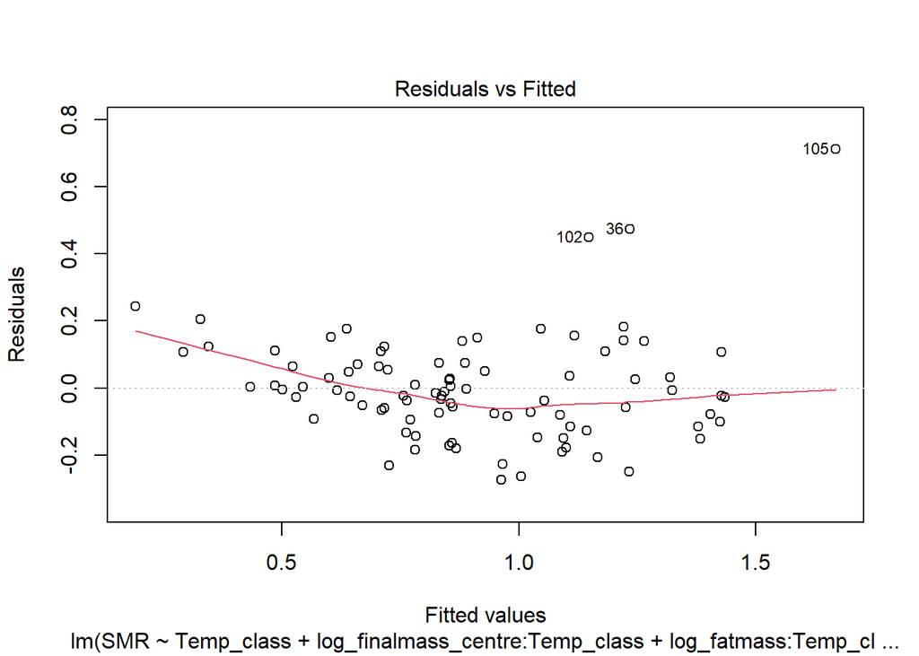

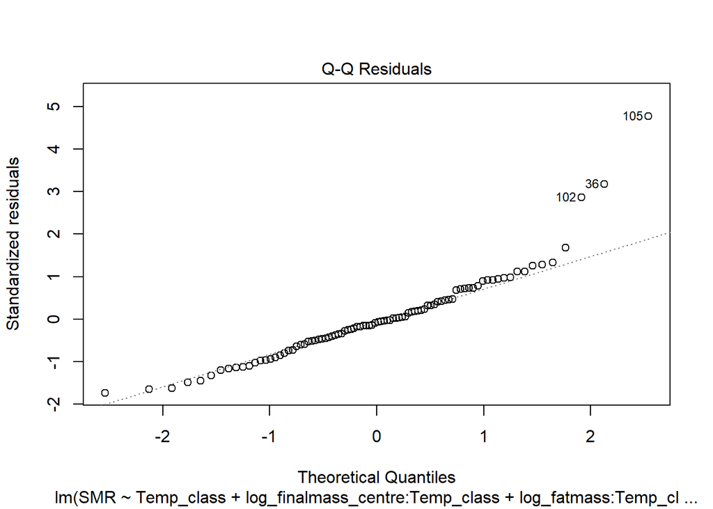

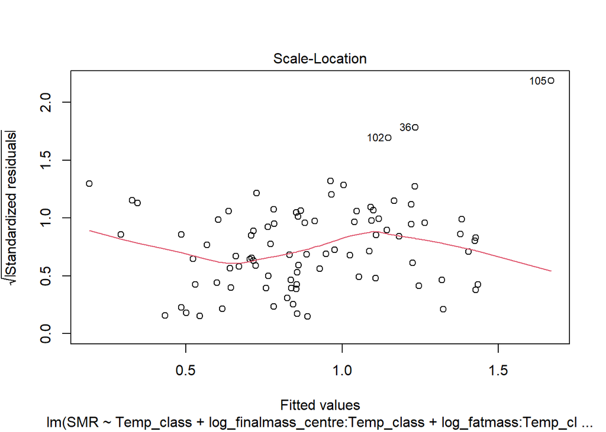

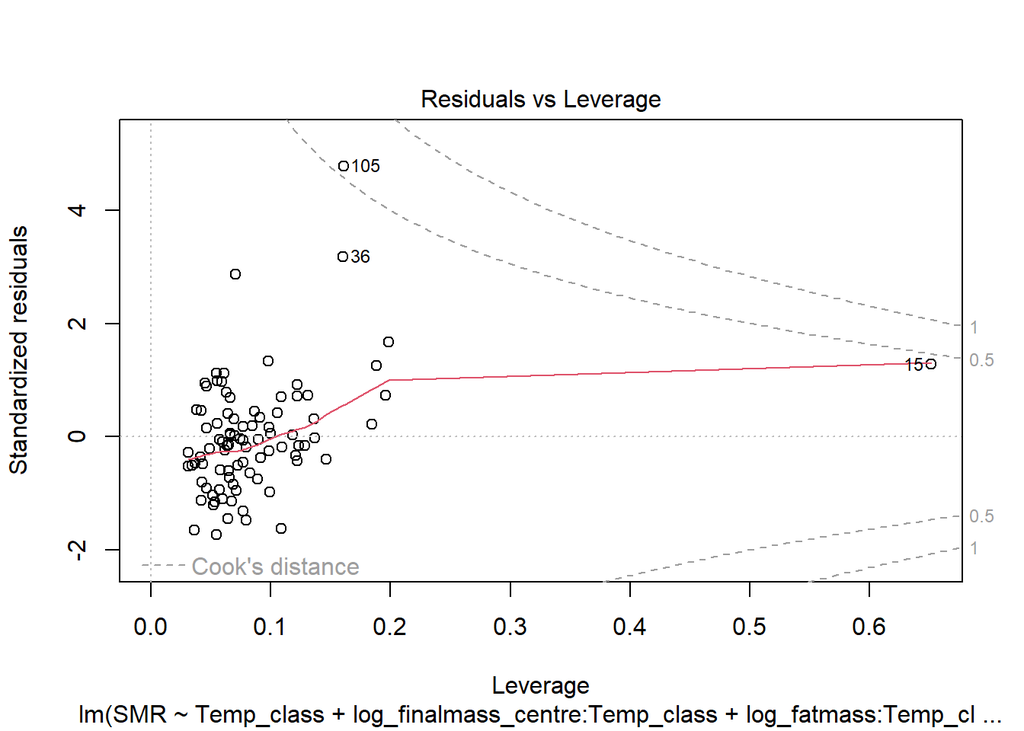

```r
# first, we build three new models:

SMR_fatmod <- lm(SMR ~ Temp_class + log_finalmass_centre:Temp_class + log_fatmass:Temp_class + Sex + Density, data=ds_fat)
RMR_fatmod <- lm(RMR ~ Temp_class + log_finalmass_centre:Temp_class + log_fatmass:Temp_class + Sex + Density, data=ds_fat)
MMR_fatmod <- lm(MMR ~ Temp_class + log_finalmass_centre:Temp_class + log_fatmass:Temp_class + Sex + Density, data=ds_fat)

# then we test those models using the summary function.

plot(SMR_fatmod)
```

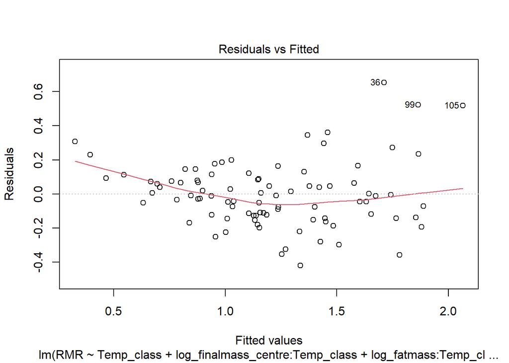

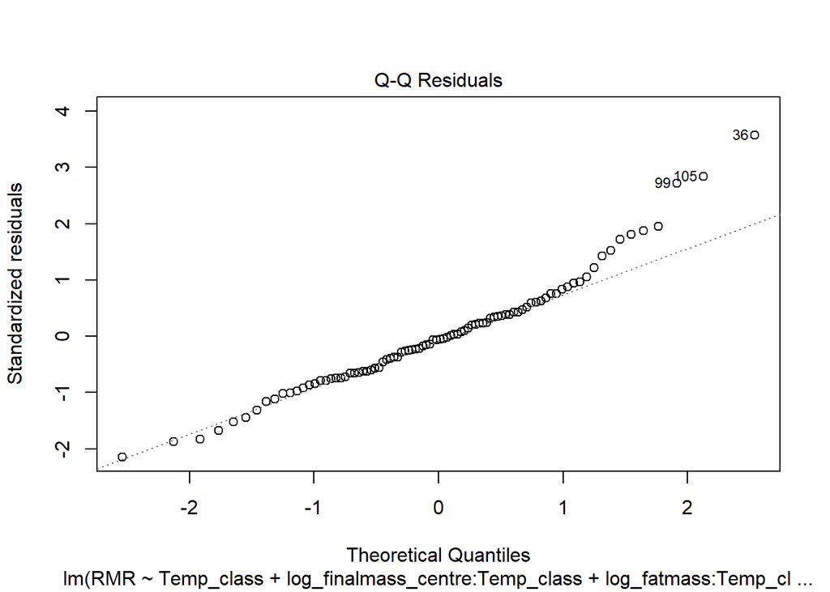

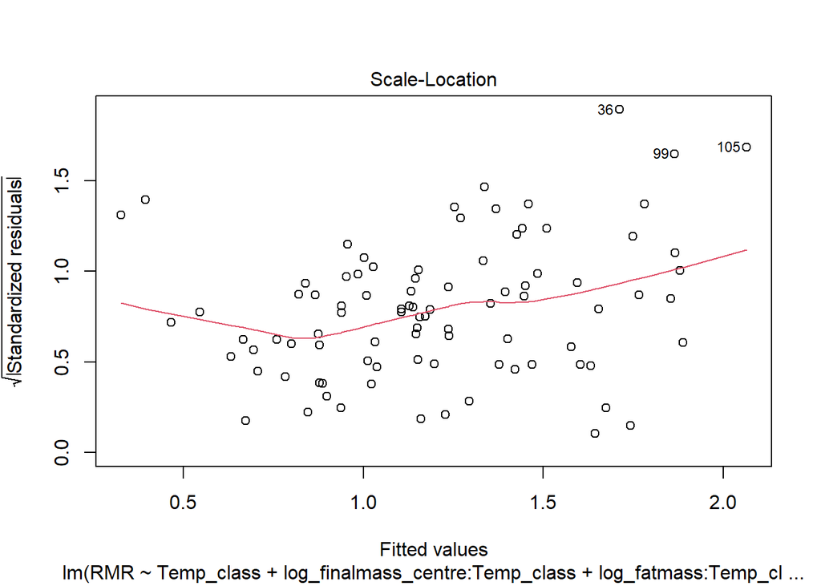

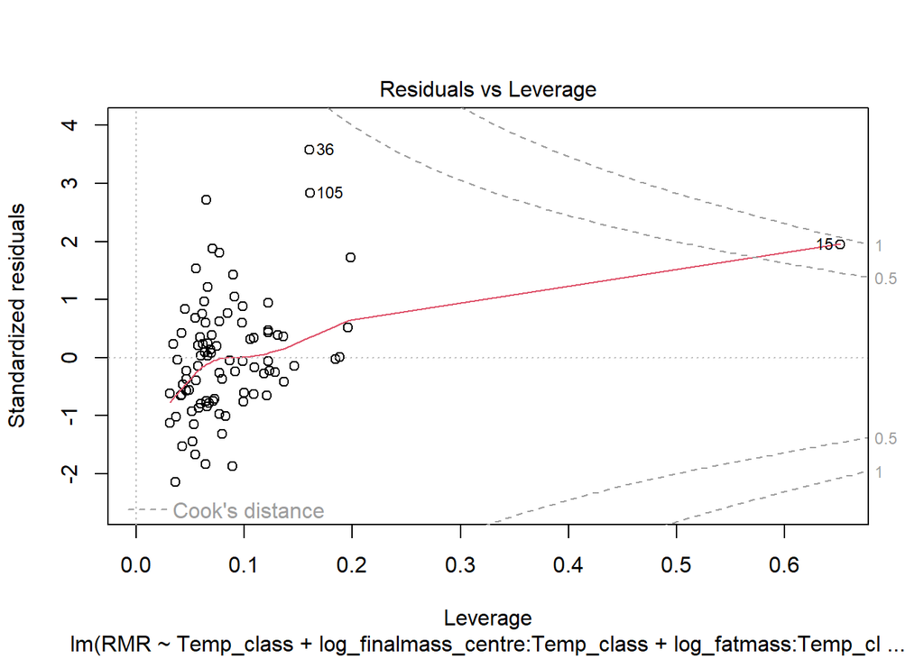

```r
plot(RMR_fatmod)
```

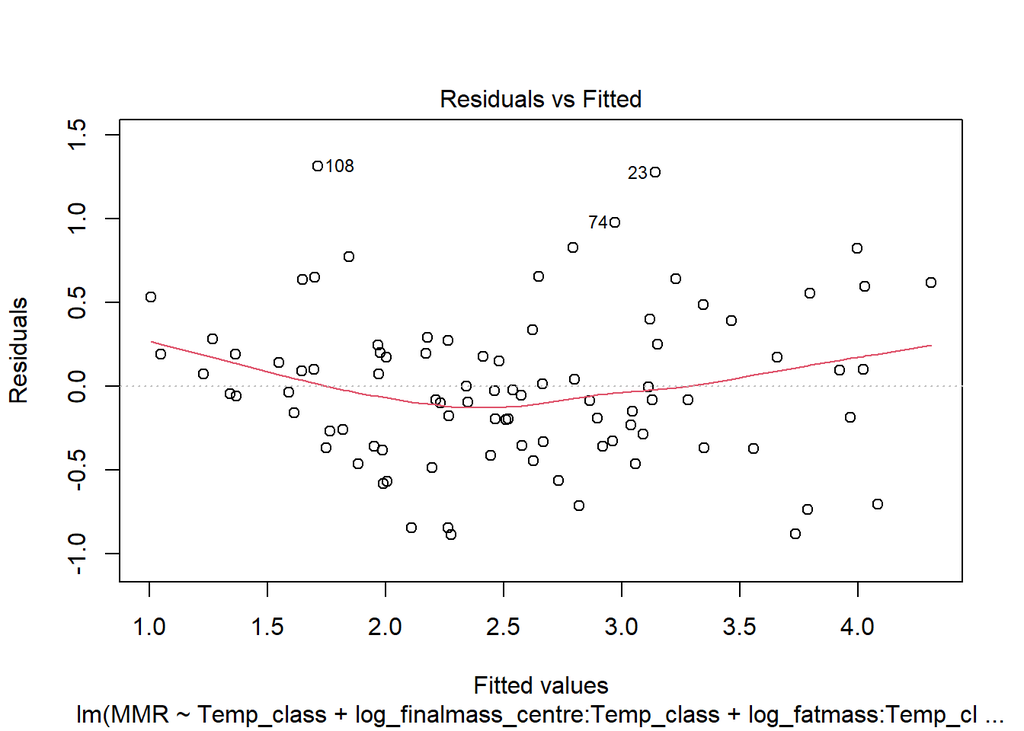

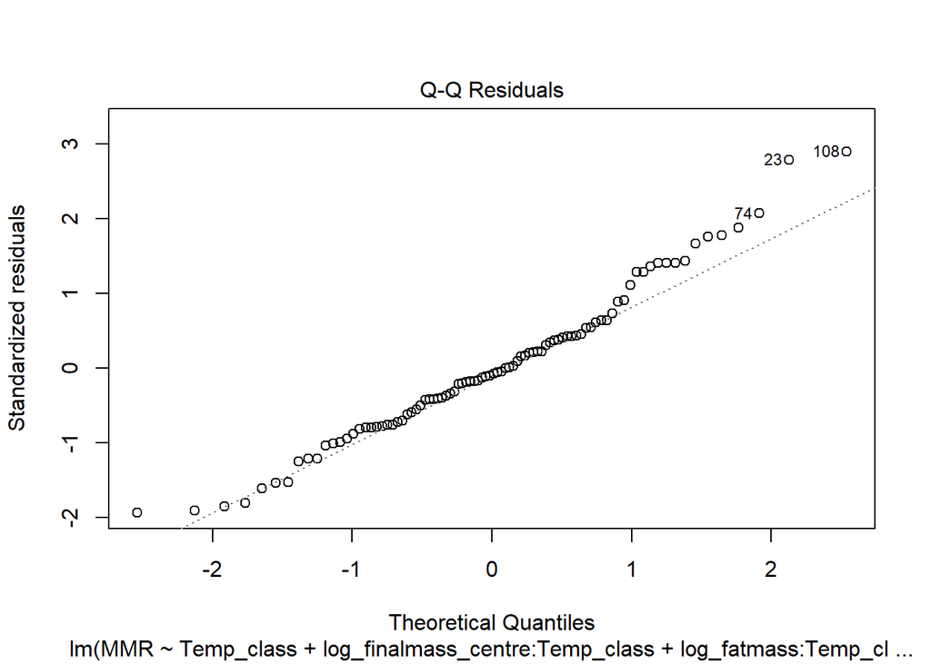

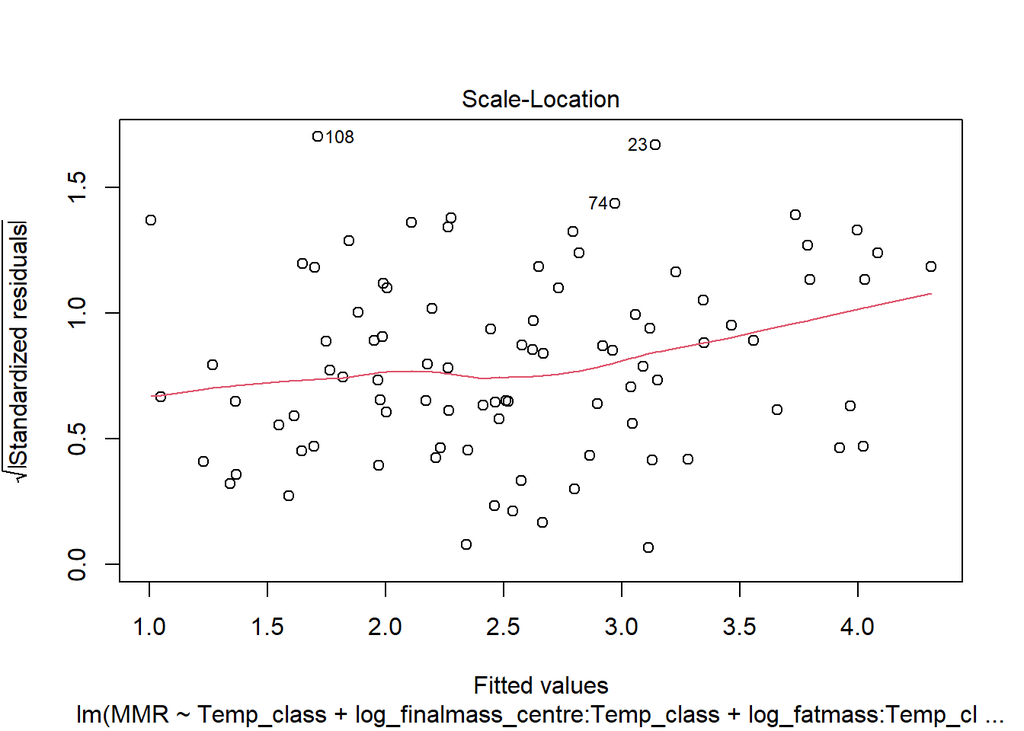

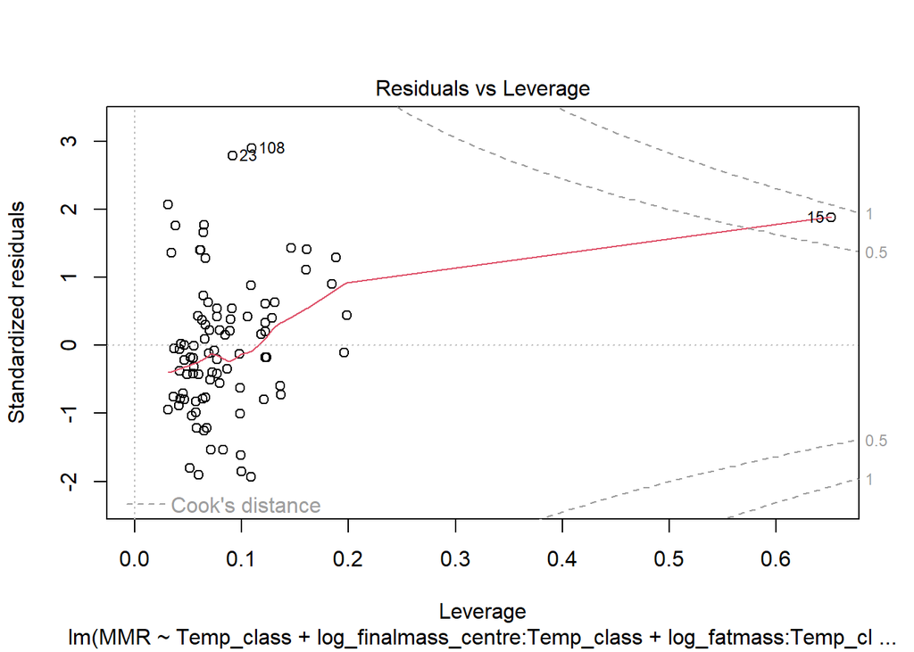

```r
plot(MMR_fatmod)
```

```r
summary(SMR_fatmod)
```

```
##
## Call:
## lm(formula = SMR ~ Temp_class + log_finalmass_centre:Temp_class +
##     log_fatmass:Temp_class + Sex + Density, data = ds_fat)
##
## Residuals:
##      Min       1Q   Median       3Q      Max
## -0.27466 -0.09074 -0.01257  0.07292  0.71167
##
## Coefficients:
##                                   Estimate Std. Error t value Pr(>|t|)
## (Intercept)                        0.32672    0.28118   1.162  0.24863
## Temp_class23                      -0.22002    0.40000  -0.550  0.58379
## SexM                               0.08185    0.03801   2.153  0.03424 *
## Density                           -0.03631    0.01216  -2.987  0.00372 **
## Temp_class18:log_finalmass_centre  1.56106    0.27294   5.719 1.68e-07 ***
## Temp_class23:log_finalmass_centre  1.69129    0.35812   4.723 9.50e-06 ***
## Temp_class18:log_fatmass           0.15233    0.14268   1.068  0.28881
## Temp_class23:log_fatmass          -0.09005    0.12955  -0.695  0.48898
## ---
## Signif. codes:  0 '***' 0.001 '**' 0.01 '*' 0.05 '.' 0.1 ' ' 1
##
## Residual standard error: 0.1627 on 82 degrees of freedom
##   (23 observations deleted due to missingness)
## Multiple R-squared:  0.7851, Adjusted R-squared:  0.7668
## F-statistic: 42.81 on 7 and 82 DF,  p-value: < 2.2e-16
```

```r
summary(RMR_fatmod)
```

```
##
## Call:
## lm(formula = RMR ~ Temp_class + log_finalmass_centre:Temp_class +
##     log_fatmass:Temp_class + Sex + Density, data = ds_fat)
##
## Residuals:
##      Min       1Q   Median       3Q      Max
## -0.42033 -0.12493 -0.01052  0.08686  0.65281
##
## Coefficients:
##                                   Estimate Std. Error t value Pr(>|t|)
## (Intercept)                        0.38315    0.34423   1.113   0.2689
## Temp_class23                      -0.29548    0.48969  -0.603   0.5479
## SexM                               0.03817    0.04654   0.820   0.4145
## Density                           -0.02908    0.01488  -1.954   0.0541 .
## Temp_class18:log_finalmass_centre  1.94813    0.33414   5.830 1.06e-07 ***
## Temp_class23:log_finalmass_centre  2.21310    0.43843   5.048 2.65e-06 ***
## Temp_class18:log_fatmass           0.15456    0.17467   0.885   0.3788
## Temp_class23:log_fatmass          -0.09350    0.15860  -0.590   0.5571
## ---
## Signif. codes:  0 '***' 0.001 '**' 0.01 '*' 0.05 '.' 0.1 ' ' 1
##
## Residual standard error: 0.1992 on 82 degrees of freedom
##   (23 observations deleted due to missingness)
## Multiple R-squared:  0.7939, Adjusted R-squared:  0.7763
## F-statistic: 45.12 on 7 and 82 DF,  p-value: < 2.2e-16
```

```r
summary(MMR_fatmod)
```

```
##
## Call:
## lm(formula = MMR ~ Temp_class + log_finalmass_centre:Temp_class +
##     log_fatmass:Temp_class + Sex + Density, data = ds_fat)
##
## Residuals:
##      Min       1Q   Median       3Q      Max
## -0.88747 -0.32888 -0.03949  0.23518  1.31385
##
## Coefficients:
##                                   Estimate Std. Error t value Pr(>|t|)
## (Intercept)                        0.06501    0.83040   0.078   0.9378
## Temp_class23                      -0.39180    1.18129  -0.332   0.7410
## SexM                               0.02876    0.11226   0.256   0.7985
## Density                           -0.06108    0.03590  -1.701   0.0926 .
## Temp_class18:log_finalmass_centre  4.83259    0.80605   5.995 5.23e-08 ***
## Temp_class23:log_finalmass_centre  4.95595    1.05762   4.686 1.09e-05 ***
## Temp_class18:log_fatmass          -0.24022    0.42135  -0.570   0.5702
## Temp_class23:log_fatmass          -0.45862    0.38259  -1.199   0.2341
## ---
## Signif. codes:  0 '***' 0.001 '**' 0.01 '*' 0.05 '.' 0.1 ' ' 1
##
## Residual standard error: 0.4805 on 82 degrees of freedom
##   (23 observations deleted due to missingness)
## Multiple R-squared:  0.7433, Adjusted R-squared:  0.7214
## F-statistic: 33.92 on 7 and 82 DF,  p-value: < 2.2e-16
```

```r
anova(SMR_fatmod)
```

```
## Analysis of Variance Table
##
## Response: SMR
##                                 Df Sum Sq Mean Sq  F value  Pr(>F)
## Temp_class                       1 0.1066  0.1066   4.0255 0.04811 *
## Sex                              1 0.0353  0.0353   1.3349 0.25130
## Density                          1 0.1460  0.1460   5.5148 0.02126 *
## Temp_class:log_finalmass_centre  2 7.6025  3.8013 143.5948 < 2e-16 ***
## Temp_class:log_fatmass           2 0.0423  0.0211   0.7982 0.45361
## Residuals                       82 2.1707  0.0265
## ---
## Signif. codes:  0 '***' 0.001 '**' 0.01 '*' 0.05 '.' 0.1 ' ' 1
```

```r
anova(RMR_fatmod)
```

```
## Analysis of Variance Table
##
## Response: RMR
##                                 Df  Sum Sq Mean Sq  F value  Pr(>F)
## Temp_class                       1  0.2208  0.2208   5.5642 0.02071 *
## Sex                              1  0.2315  0.2315   5.8360 0.01792 *
## Density                          1  0.0573  0.0573   1.4438 0.23298
## Temp_class:log_finalmass_centre  2 11.9762  5.9881 150.9284 < 2e-16 ***
## Temp_class:log_fatmass           2  0.0441  0.0221   0.5559 0.57570
## Residuals                       82  3.2533  0.0397
## ---
## Signif. codes:  0 '***' 0.001 '**' 0.01 '*' 0.05 '.' 0.1 ' ' 1
```

```r
anova(MMR_fatmod)
```

```
## Analysis of Variance Table
##
## Response: MMR
##                                 Df Sum Sq Mean Sq  F value    Pr(>F)
## Temp_class                       1  5.346  5.3458  23.1539 6.716e-06 ***
## Sex                              1  1.529  1.5285   6.6206   0.01188 *
## Density                          1  0.235  0.2350   1.0178   0.31602
## Temp_class:log_finalmass_centre  2 47.297 23.6485 102.4280 < 2.2e-16 ***
## Temp_class:log_fatmass           2  0.413  0.2064   0.8938   0.41305
## Residuals                       82 18.932  0.2309
## ---
## Signif. codes:  0 '***' 0.001 '**' 0.01 '*' 0.05 '.' 0.1 ' ' 1
```

```r
# here again, none of our models find any significant correlation between the interaction between temperature and fat mass with any metabolic trait. Our results do not support Prediction 2.
```

This model is excluded from the following covariance matrix because we were only able to collect one measurement of fat mass from each fish, all at the very end of the experiment. Without an initial measurement of fat mass (logistically impossible as it was a lethal measurement), we are unable to assess within-subject residual correlation. For this reason, we have assessed it separately.

```r
ds1 <- ds1 %>%
  mutate(
    Sex = as.character(Sex),
    Sex = if_else(is.na(Sex), " ", Sex),
    Sex = as.factor(Sex))
```

# COVARIANCE MATRIX

## build covariance matrix with brms

```r
RN <- bf(mass1 ~ 0 + Temp_class + Month_centred_factor:Temp_class + Sex + Density + (1 + Month_centred |a| ID_fish)) +
      bf(SMR1  ~ 0 + Temp_class + log_mass_centre:Temp_class + Sex + Density + (1 |a| ID_fish)) +
      bf(RMR1  ~ 0 + Temp_class + log_mass_centre:Temp_class + Sex + Density + (1 |a| ID_fish)) +
      bf(MMR1  ~ 0 + Temp_class + log_mass_centre:Temp_class + Sex + Density + (1 |a| ID_fish)) +
      set_rescor(T)

prior1 <- c(set_prior("normal(0,2)", class = "b", resp = c("mass1", "SMR1", "RMR1","MMR1")),
            set_prior("cauchy(0,2)", class = "sd", resp = c("mass1", "SMR1", "RMR1","MMR1")),
            set_prior("lkj(2)", class = "cor"))

 fit1 <- brm(formula = RN,
            data = ds1,
            prior = prior1,
            seed = 42, warmup = 500, iter = 10000, chains = 4, cores = 4,
            control=list(adapt_delta=0.97, max_treedepth = 15),
            save_ranef = T
           )

print(fit1, digits = 3)
```

```
##  Family: MV(gaussian, gaussian, gaussian, gaussian)
##   Links: mu = identity
##          mu = identity
##          mu = identity
##          mu = identity
## Formula: mass1 ~ 0 + Temp_class + Month_centred_factor:Temp_class + Sex + Density + (1 + Month_centred | a | ID_fish)
##          SMR1 ~ 0 + Temp_class + log_mass_centre:Temp_class + Sex + Density + (1 | a | ID_fish)
##          RMR1 ~ 0 + Temp_class + log_mass_centre:Temp_class + Sex + Density + (1 | a | ID_fish)
##          MMR1 ~ 0 + Temp_class + log_mass_centre:Temp_class + Sex + Density + (1 | a | ID_fish)
##    Data: ds1 (Number of observations: 624)
##   Draws: 4 chains, each with iter = 10000; warmup = 500; thin = 1;
##          total post-warmup draws = 38000
##
## Multilevel Hyperparameters:
## ~ID_fish (Number of levels: 136)
##                                          Estimate Est.Error l-95% CI u-95% CI
## sd(mass1_Intercept)                         0.180     0.012    0.158    0.206
## sd(mass1_Month_centred)                     0.042     0.003    0.036    0.050
## sd(SMR1_Intercept)                          0.016     0.006    0.002    0.028
## sd(RMR1_Intercept)                          0.034     0.005    0.025    0.044
## sd(MMR1_Intercept)                          0.036     0.004    0.027    0.045
## cor(mass1_Intercept,mass1_Month_centred)   -0.344     0.088   -0.507   -0.162
## cor(mass1_Intercept,SMR1_Intercept)        -0.237     0.255   -0.696    0.296
## cor(mass1_Month_centred,SMR1_Intercept)     0.421     0.220   -0.070    0.786
## cor(mass1_Intercept,RMR1_Intercept)         0.011     0.139   -0.263    0.279
## cor(mass1_Month_centred,RMR1_Intercept)     0.231     0.126   -0.022    0.471
## cor(SMR1_Intercept,RMR1_Intercept)          0.591     0.236   -0.069    0.874
## cor(mass1_Intercept,MMR1_Intercept)        -0.163     0.139   -0.428    0.118
## cor(mass1_Month_centred,MMR1_Intercept)     0.363     0.118    0.122    0.584
## cor(SMR1_Intercept,MMR1_Intercept)          0.184     0.256   -0.347    0.653
## cor(RMR1_Intercept,MMR1_Intercept)          0.353     0.138    0.066    0.604
##                                           Rhat Bulk_ESS Tail_ESS
## sd(mass1_Intercept)                      1.000     6085    11761
## sd(mass1_Month_centred)                  1.001     7416    13264
## sd(SMR1_Intercept)                       1.001     3293     2701
## sd(RMR1_Intercept)                       1.002     2093     3340
## sd(MMR1_Intercept)                       1.000    14112    20556
## cor(mass1_Intercept,mass1_Month_centred) 1.001     7215    13469
## cor(mass1_Intercept,SMR1_Intercept)      1.000    15902    20460
## cor(mass1_Month_centred,SMR1_Intercept)  1.000    17629    10466
```

[output cut: 84 more lines]

```
## sigma_RMR1     0.079     0.003    0.074    0.084 1.001     9284    22087
## sigma_MMR1     0.068     0.002    0.064    0.072 1.000    26603    27412
##
## Residual Correlations:
##                    Estimate Est.Error l-95% CI u-95% CI  Rhat Bulk_ESS Tail_ESS
## rescor(mass1,SMR1)    0.013     0.065   -0.113    0.139 1.000    13620    22523
## rescor(mass1,RMR1)    0.014     0.062   -0.108    0.135 1.000    13417    21624
## rescor(SMR1,RMR1)     0.865     0.011    0.842    0.885 1.000    13917    25981
## rescor(mass1,MMR1)   -0.014     0.059   -0.130    0.102 1.001    19527    28054
## rescor(SMR1,MMR1)     0.163     0.043    0.078    0.246 1.000    19731    25365
## rescor(RMR1,MMR1)     0.233     0.042    0.149    0.315 1.000    22805    29895
##
## Draws were sampled using sampling(NUTS). For each parameter, Bulk_ESS
## and Tail_ESS are effective sample size measures, and Rhat is the potential
## scale reduction factor on split chains (at convergence, Rhat = 1).
```